# Diseño de experimentos

**El diseño de experimentos** consiste en cómo estructurar el entorno experimental, cómo asignar los factores, y cómo analizar los datos obtenidos a través del experimento para obtener la información necesaria.

- Enfoque en dominar los métodos de cálculo para experimentos de un solo factor (One-way ANOVA), la creación de la tabla de análisis de varianza (ANOVA), y las cálculos y explicaciones para las pruebas de hipótesis y la estimación.
- Se busca que el alumno domine el cálculo para experimentos de dos factores con repeticiones, la creación de la tabla de análisis de varianza (ANOVA), y el cálculo y la explicación de las pruebas de hipótesis y la estimación, considerando la presencia o ausencia de interacción.
- El objetivo es que la persona sea capaz de dominar los métodos de cálculo para experimentos de dos factores sin repeticiones, la creación de la tabla de análisis de varianza (ANOVA), y los cálculos y explicaciones para las pruebas de hipótesis y la estimación.

[Audio_1](https://drive.google.com/file/d/1gIDLmZPfm39s--ozE-Ur8Dtiu1c3_cYx/view?usp=drive_link)

```python
import os
import sys
try:
  os.chdir('../Python/QCKentei2')
except:
  pass
sys.path.append(os.path.abspath(os.path.join("..","Common")))
path = os.getcwd()
```

```python
import pandas as pd
import numpy as np
import matplotlib.pyplot as plt
import seaborn as sns


from IPython.display import display
import base64

import statsmodels.api as sm
import statsmodels.formula.api as smf
from statsmodels.formula.api import ols
import scipy.stats as stats

from collections import defaultdict

import gspread
from google.oauth2.service_account import Credentials

import importlib
import anova # type: ignore
import chart #type:ignore
```

## Diseño de experimentos

実験計画法

### 1. ¿Qué es el diseño de experimentos?

実験計画法とは

**El diseño de experimentos** es un término general para la metodología estadística que indica cómo recolectar datos de manera planificada y cómo analizarlos.

El objetivo del **diseño de experimentos** es identificar qué **factores** influyen en el **valor de una característica** y, si lo hacen, determinar cómo ajustar los valores (**niveles**) de esos factores para obtener un valor específico de la característica.

### 2. Procedimiento de experimentación y análisis:

実験と解析の手順

En el diseño de experimentos, se planifican y ejecutan experimentos, y luego se analizan los datos obtenidos.

1. Determinar el objetivo de experimento y la característica de calidad (**valor característico**).
2. Seleccionar los **factores** a considerar, por ejemplo, a partir de un diagrama de causa y efecto.
3. Establecer los niveles de los **factores**.
4. Asignar los **factores** al diseño experimental.
5. Determinar el **orden de realización del experimento**.
6. Realizar el **experimento**.
7. **Analizar los datos obtenidos** (análisis de varianza).
8. Derivar **conclusiones** a partir de los resultados del análisis y la información técnica.

### 3. Tipos de experimentos:

実験計画法の種類

1. **Experimento de un solo factor** (Diseño de un solo factor) １元配置実験
2. **Experimento de dos factores** (Diseño de dos factores) ２元配置実験
3. **Experimento multifactorial** (Diseño multifactorial) 多元配置実験
- Aleatorización completa / Aleatorización totalmente al azar
1. Método de división (Diseño dividido o diseño en parcelas divididas)
2. Experimento con tablas ortogonales (Diseño basado en matrices ortogonales)

### 4. Términos del diseño de experimentos:

実験計画法の用語

1. Factor （因子）
2. Nivel （水準）
3. Número de niveles （水準数）
4. Repetición / Réplicas （繰り返し）
5. Efecto principal （主効果）
6. Interacción （交互作用）
7. Error （誤差）
8. Factor （要因）
9. Aleatorización / Randomización （ランダム化）

### 5. Métodos experimentales (**Los tres principios de Fisher**)

フィッシャーの３原則

1. **Repetición** (Repetición de experimentos)
- Realizar múltiples observaciones bajo las mismas condiciones para estimar el error experimental.
1. **Aleatorización** (Randomización)
- Asignar tratamiento o condiciones experimentales de manera aleatoria para evitar sesgos sistemáticos.
1. **Bloqueo** (Bloques o diseño en bloques)
- Agrupar unidades experimentales homogéneas en bloques para reducir la variabilidad no controlada.

[Audio_2](https://drive.google.com/file/d/1RSgBI8kbiiEAZLKiS3s6vOz-rvQ1oV9b/view?usp=drive_link)

## 07-02 Experimento de un solo factor

１元配置実験

### 1. ¿Qué es un experimento de un solo factor?

一元配置実験とは

Un experimento de un solo factor es un diseño experimental en el cual se estudia el efecto de un único factor (variable independiente) sobre una variable de respuesta, manteniendo constantes todos los demás factores.

### 2. Procedimiento de análisis de un experimento de un solo factor.

一元配置実験の解析の手順

#### (1) Formato de datos de un experimento de un factor

一元配置実験のデータ形式

- Se establecen $ l $ niveles de $ A_1 $ a $ A_l $, se realizan $ r $ repeticiones experimentales para cada nivel. **Repetición** no se refiere solo a la repetición de medición, sino a la **repetición de todo el experimento**, incluyendo la configuración del nivel. Luego, se realizan las $ N = l \times r $ experimentos en un orden aleatorio.

[Audio_3](https://drive.google.com/file/d/1QDo3cE0OfzNugC3cdsx-kLzSPiT6ki8R/view?usp=drive_link)

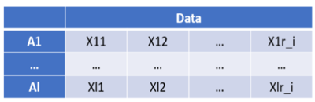

```python
from PIL import Image
img = Image.open('./Data2/7-1.png')

resized_img = img.resize((400, 130))
display(resized_img)
```

#### (2) Modelo de estructura de datos de un experimento de un factor

一元配置実験のデータ構造式

En el caso de un experimento de un factor, el modelo de estructura para el j-ésimo data $ x_{ij} $ obtenido en el nivel $ A_i $ es el siguiente.

$ x_{ij} = \mu + a_i + \epsilon_{ij}$

$ \mu $: Media general

$ a_i $: Efecto principal del factor A ($ i = 1,2,..., l) $), $ \sum a_i = 0 $

$ \epsilon_{ij} $: Error($ j = 1, 2, ..., r_i $), $ \epsilon \sim N(0, \sigma^2) $

#### (3) Descomposición de la variabilidad y cálculo de la suma de cuadrados.

バラツキの分解と平方和の計算

El análisis de varianza (ANOVA) es un método para analizar la variabilidad (varianza) dividiéndola en componentes.

1. Calcular la media de cada grupo (nivel del factor).
2. Calcular la media general.
3. Calcular la suma de cuadrados total (SCT), la suma de cuadrados entre grupos (SCB) y la suma de cuadrados dentro de los grupos o del error (SCE).
4. Calcular los cuadrados medios (CM): CM entre grupos y CM del error.
5. Comparar el estadístico F (F: CM entre grupos / CM del error).
6. Comparar el valor F con el valor crítico de la tabla F para determinar si hay diferencias significativas entre los niveles.
7. Si se detectan diferencias significativas, realizar comparaciones múltiples (como Tukey y Bonferroni) para identificar qué niveles diferen.

[Audio_4](https://drive.google.com/file/d/1vnqL4gNhZa7V64DSQbc1EOIi28G4xmVk/view?usp=drive_link)

３種類の樹脂（A1〜A3）の強度に差があるかどうかを検討することになった。そこで繰り返しを３回として9回の実験をランダムに行い、表７.２のデータを得た。データはバラついているが、このばらつきを樹脂の種類の違いによるばらつきと、それ以外のばらつき（実験誤差）に分ける。

Se decidió examinar si hay diferencias en la resistencia entre tres tipos de resinas (A1 a A3). Para ello, se realizaron nueve experimentos de forma aleatoria, con tres repeticiones para cada tipo. Los datos obtenidos se muestran en la Tabla 7.2. Aunque los datos presentan variabilidad, esta variabilidad se divide en la causada por las diferencia entre los tipos de resina y la causada por otros factores (**error experimental**).

```python
SERVICE_ACCOUNT_FILE = "my-project-vscode-452201-249bdb033f8c.json"  # JSONファイルのパス
SCOPES = ["https://www.googleapis.com/auth/spreadsheets"]

credentials = Credentials.from_service_account_file(SERVICE_ACCOUNT_FILE, scopes=SCOPES)
client = gspread.authorize(credentials)

# スプレッドシートを開く（URLまたはスプレッドシートIDを使用）
SPREADSHEET_ID = "1Ma7ehT4TAnkUwJjspP-C3mwJA1hYmbJr8B9GJSFI0lU"
sheet = client.open_by_key(SPREADSHEET_ID).worksheet("Sheet23") # 最初のシートを取得

# データを取得
list_of_lists = sheet.get_all_records()
df = pd.DataFrame(list_of_lists)
df = df.set_index("A")
df = df.astype(float)

df0 = df.copy()
df['group_mean'] = df.mean(axis=1)
mean_total = df['group_mean'].mean()

print("Tabla 7.2")
print(f'\nMedia global: {mean_total}')

df
```

```
Tabla 7.2

Media global: 14.0
```

| A | r1 | r2 | r3 | group_mean |
| --- | --- | --- | --- | --- |
| A1 | 16.0 | 12.0 | 14.0 | 14.0 |
| A2 | 13.0 | 12.0 | 11.0 | 12.0 |
| A3 | 18.0 | 16.0 | 14.0 | 16.0 |

```python
import webbrowser

url = "https://docs.google.com/spreadsheets/d/" + SPREADSHEET_ID
#webbrowser.open(url)
```

```python
def dict0(df):
    result = df.to_dict(orient='index')
    dict0 = {k:list(v.values()) for k, v in result.items()}
    return  dict0
data2 = dict0(df0)
```

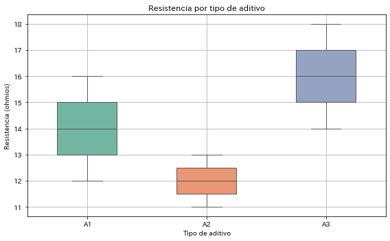

```python
data = df0.to_dict()
records = []
for rep, cond_dict in data.items():
    for factor, value in cond_dict.items():
        records.append({'A': factor, 'x': value})

df_ = pd.DataFrame(records)

# 可視化：箱ひげ図
plt.figure(figsize=(8, 5))

# 箱ひげ図
sns.boxplot(x="A", y="x", data=df_, hue="A", palette="Set2", width=0.5, legend=False)


plt.title("Resistencia por tipo de aditivo")
plt.xlabel("Tipo de aditivo")
plt.ylabel("Resistencia (ohmios)")
plt.grid(True)
plt.tight_layout()
plt.show()
```

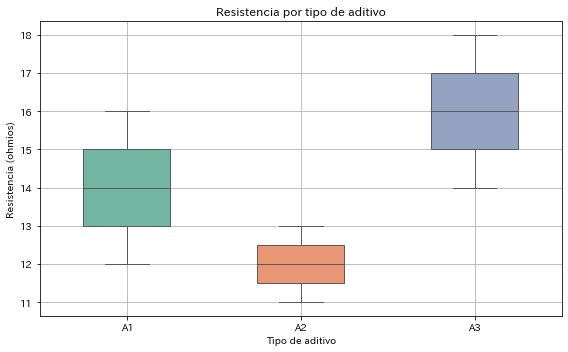

```python
from chart import BoxChart2 # type: ignore

chart = BoxChart2(df0, x='A', y='x', hue='A', title="Resistencia por tipo de aditivo", xlabel="Tipo de aditivo", ylabel="Resistencia (ohmios)")
fig = chart.box_chart2()

plt.show()
```

#### (3) Descomposición de la variabilidad y cálculo de las sumas de cuadrados

バラツキの分解と平方和の計算

Dados los datos $ x_{ij} $, la media de los datos de resistencia para cada resina $ \bar{x}_{i*} $, y la media de todos los datos $ \bar{x} $, veamos los datos de la Tabla 7.2 divididos en $ x_{ij} = ( \bar{x}_{i*} - \bar{x}) + (x_{ij} - \bar{x}_{i*}) $.

Como los datos contienen valores positivos y negativos, para evaluar la dispersión es necesario elevar al cuadrado cada uno de ellos.

- SST: Suma Total de Cuadrados
- SSA: Suma de Cuadrados entre grupos A
- SSE: Suma de Cuadrados del Error

```python
df0_numpy = df0.to_numpy()
ST = df0.values.mean()
SA = (df0.mean(axis=1).to_numpy() -ST)

st = df0_numpy -ST
sa = np.tile(SA.reshape(-1,1),(1,3))
se = st-sa

print(f"st:\n{st} \n= sa:\n{sa} \n + se:\n{se}")

SST = (st**2).sum()
SSA = (sa**2).sum()
SSE = (se**2).sum()

print(f"\nSST:{SST} SSA:{SSA} SSE:{SSE}")
```

```
st:
[[ 2. -2.  0.]
 [-1. -2. -3.]
 [ 4.  2.  0.]]
= sa:
[[ 0.  0.  0.]
 [-2. -2. -2.]
 [ 2.  2.  2.]]
 + se:
[[ 2. -2.  0.]
 [ 1.  0. -1.]
 [ 2.  0. -2.]]

SST:42.0 SSA:24.0 SSE:18.0
```

```python
from collections import defaultdict

nested_dict = df0.to_dict()

# 初期化
data = defaultdict(list)

# ネストされた辞書を走査して変換
for _, inner_dict in nested_dict.items():
    for key, value in inner_dict.items():
        data[key].append(value)

# 通常の辞書に変換
data = dict(data)
data2 = data.copy()
df2 = pd.DataFrame(data2).T
print(df2)
```

```
       0     1     2
A1  16.0  12.0  14.0
A2  13.0  12.0  11.0
A3  18.0  16.0  14.0
```

#### (4) Creación de la tabla ANOVA

```python
from anova import Anova00  # type: ignore

anova = Anova00(df0, a=1, b=1)
anova_table, message = anova.creacion_ANOVA()
display(anova_table)

print(message)
```

|  | Suma de cuadrados (SS) | Grado de libertad (df) | Suma de cuadrados (MS) | Valor F |
| --- | --- | --- | --- | --- |
| Entre grupos | 24.0 | 2 | 12.0 | 4.0 |
| Error | 18.0 | 6 | 3.0 |  |
| Total | 42.0 | 8 |  |  |

```
=== Prueba de significacia ===
Valor crítical del 5% de la distribución F (2, 6) = 5.143
Valor F obervado = 4.000
Valor p = 0.079
⇒ No se puede recharzar la hipótesis nula: no existe una diferencia significativa entre los nileles.

=== Media poblacional de cada nivel y su intervalo de confianza del 95% ===
A1: Estimación puntual = 14.00, 95% CI = (11.55, 16.45)
A2: Estimación puntual = 12.00, 95% CI = (9.55, 14.45)
A3: Estimación puntual = 16.00, 95% CI = (13.55, 18.45)
```

```python
def creacion_ANOVA(df, a=0, b=0):

    # Diseño experimental
    k = df.shape[0]  # Número de niveles
    N = df.count().sum()
    ni = df.count(axis=1)   # Número de repeticiones por grupo

    # Medio
    group_means = df.mean(axis=1, skipna=True)
    grand_mean = df.stack().mean()

    # Suma de cuadrados entre grupos A (SSA)
    SSA = sum(ni * (group_means - grand_mean) ** 2)
    # Suma total de cuadrados (SST)
    SST = sum((df.stack() - grand_mean) ** 2)
    # Suma de cuadrados del error (SSE)
    SSE = SST - SSA

    # Grados de libertad
    dfA = k - 1
    dfE = N - k
    dfT = N - 1

    # Cuadrado medio
    MSA = SSA / dfA
    MSE = SSE / dfE

    # Valor F
    F = MSA / MSE
    F = np.round(F,3)

    # Crear una tabla de descomposición
    anova_table = pd.DataFrame({
        'Suma de cuadrados (SS)': [SSA, SSE, SST],
        'Grado de libertad (df)': [dfA, dfE, dfT],
        'Suma de cuadrados (MS)': [MSA, MSE, ''],
        'Valor F': [F, '', '']
    }, index=['Entre grupos', 'Error', 'Total'])

    message = ""
    alpha = 0.05  # 有意水準


    if a == 1:
        # Prueba de significancia (comparación con el punto superior del 5% de la distribución F)
        F_crit = stats.f.ppf(1 - alpha, dfA, dfE)
        p_value = 1 - stats.f.cdf(F, dfA, dfE)

        message += "=== Prueba de significacia ===\n"
        message += f"Valor crítical del 5% de la distribución F ({dfA}, {dfE}) = {F_crit:.3f}\n"
        message += f"Valor F obervado = {F:.3f}\n"
        message += f"Valor p = {p_value:.3f}\n"

        if F > F_crit:
            message += "⇒ Se rechaza la hipótesis nula: existe una diferencia significativa entre los niveles.\n"
        else:
            message += "⇒ No se puede rechazar la hipótesis nula: no existe una diferencia significativa entre los niveles.\n"

        group_means = df.mean(axis=1)
        n = df.shape[0]  # 各群の繰り返し数
        t_crit = stats.t.ppf(1 - alpha / 2, dfE)  # t(6, 0.975)

        if b==1:
            message += "\n=== Media poblacional de cada nivel y su intervalo de confianza del 95% ===\n"
            for group, mean in group_means.items():
                se = np.sqrt(MSE / n)  # 標準誤差
                ci_low = mean - t_crit * se
                ci_high = mean + t_crit * se
                message += f"{group}: Estimación puntual = {mean:.2f}, 95% CI = ({ci_low:.2f}, {ci_high:.2f})\n"

    return anova_table, message
```

```python
from anova import Anova # type: ignore

anova_tabla, message = creacion_ANOVA(df0, a=1, b=1)

display(anova_tabla.round(2))
print(message)
```

|  | Suma de cuadrados (SS) | Grado de libertad (df) | Suma de cuadrados (MS) | Valor F |
| --- | --- | --- | --- | --- |
| Entre grupos | 24.0 | 2 | 12.0 | 4.0 |
| Error | 18.0 | 6 | 3.0 |  |
| Total | 42.0 | 8 |  |  |

```
=== Prueba de significacia ===
Valor crítical del 5% de la distribución F (2, 6) = 5.143
Valor F obervado = 4.000
Valor p = 0.079
⇒ No se puede rechazar la hipótesis nula: no existe una diferencia significativa entre los niveles.

=== Media poblacional de cada nivel y su intervalo de confianza del 95% ===
A1: Estimación puntual = 14.00, 95% CI = (11.55, 16.45)
A2: Estimación puntual = 12.00, 95% CI = (9.55, 14.45)
A3: Estimación puntual = 16.00, 95% CI = (13.55, 18.45)
```

```python
df = pd.DataFrame(records)

# Step 2: ANOVA（分散分析）
model = smf.ols('x ~ C(A)', data=df).fit()
anova_table = sm.stats.anova_lm(model, typ=1)

# 結果表示
print("【ANOVA】")
display(anova_table)
```

```
【ANOVA】
```

|  | df | sum_sq | mean_sq | F | PR(>F) |
| --- | --- | --- | --- | --- | --- |
| C(A) | 2.0 | 24.0 | 12.0 | 4.0 | 0.078717 |
| Residual | 6.0 | 18.0 | 3.0 | NaN | NaN |

#### (5) Estimación posterior al análisis de varianza

分散分析後の推定

Estimación puntual e intervalo de confianza con un nivel de confianza de (1 - $ \alpha $)

(1) ¿Cuál es la media poblacional en un nivel determinado?

- $ \hat{\mu} (A_i) = \hat{\mu + \alpha_i} = \bar{x}_{i*} = \frac{T_{i*}}{r_i} $
- $ \hat{\mu} (A_i) \pm t(\phi_E, \alpha) \sqrt{V_E / r_i} $

(2) ¿Cuál es la diferencia entre las poblaciones de un nivel y otro nivel?

- $ \hat{\mu} (A_i) - \hat{\mu} (A_i') = \hat{\mu + \alpha_i} - \hat{\mu + \alpha_{i'}} = \bar{x}_{i*} - \bar{x}_{i'*} = \frac{T_{i*}}{r_i} - \frac{T_{i*}}{r_{i'}} $
  - $ \hat{\mu} (A_i) - \hat{\mu} (A_i') \pm t(\phi_E, \alpha) \sqrt{(1 / r_i + 1 / r_{i'}) V_E} $

  [Audio_5](https://drive.google.com/file/d/1XairUOCOKd5S9nomxPSlLP2VK8gUOJ5-/view?usp=drive_link)

```python
from scipy.stats import bartlett, levene

def bartlett_levene(data, center='median', verbose=True):
    """
    任意の群数に対して、バートレット検定とレビーン検定を行う汎用関数。

    Parameters:
        data (dict): {'group_name1': [values], 'group_name2': [values], ...}
        center (str): レビーン検定の中心値基準（'mean', 'median', 'trimmed'）
        verbose (bool): 結果を出力するか（True: print, False: return dictのみ）

    Returns:
        dict: {
            'bartlett': {'statistic': ..., 'pvalue': ...},
            'levene':   {'statistic': ..., 'pvalue': ...}
        }
    """

    groups = list(data.values())

    # 検定の実行
    bart_stat, bart_p = bartlett(*groups)
    lev_stat, lev_p = levene(*groups, center=center)

    results = {
        'bartlett': {'statistic': bart_stat, 'pvalue': bart_p},
        'levene':   {'statistic': lev_stat, 'pvalue': lev_p}
    }

    if verbose:
        print("🔎 バートレット検定:")
        print(f"  統計量 = {bart_stat:.4f}, p値 = {bart_p:.4f}")
        print("➡️ 正規性があるなら p < 0.05 で分散に有意差あり\n")

        print("🔎 レビーン検定:")
        print(f"  統計量 = {lev_stat:.4f}, p値 = {lev_p:.4f}")
        print("➡️ p < 0.05 なら分散に有意差あり（より頑健）")

    return results
```

```python
data = dict0(df0)
bartlett_levene(data)
```

```
🔎 バートレット検定:
  統計量 = 0.8562, p値 = 0.6517
➡️ 正規性があるなら p < 0.05 で分散に有意差あり

🔎 レビーン検定:
  統計量 = 0.4444, p値 = 0.6607
➡️ p < 0.05 なら分散に有意差あり（より頑健）
```

```
{'bartlett': {'statistic': np.float64(0.8562242352510785),
  'pvalue': np.float64(0.6517383393472049)},
 'levene': {'statistic': np.float64(0.44444444444444425),
  'pvalue': np.float64(0.6607028968480416)}}
```

#### (6) Análisis de Varianza (ANOVA) de un Factor.

一元配置実験の分散分析の手順

## 7.1

電子部品の重要な特性の一つに導体抵抗（単位：オーム）がある。添加剤の種類（$ A_1 - A_3 $）により導体の抵抗に変化があるかどうかを調べるために、それぞれの添加剤ごとに繰り返し４回、計１２回の実験をランダムに実施した。その結果を表７．７にしめす。分散分析を行い、要因効果の有無を検討せよ。

Una de las caraterísticas importantes de los componentes electrónicos es la resistencia del conductor (unidad: ohomios).

Para investigar si el tipo de aditivo ($ A_1 - A_3 $) influye en la resistencia del conductor, se realizaron 12 experimentos en total, con 4 repeticiones para cada tipo de aditivo, ejecutados de forma aleatoria.

Los resultados se muestran en la Tabla 7.7.

Realice un análisis de varianza (ANOVA) y evalúe si el factor tiene un efecto significativo.

```python
# スプレッドシートを開く（URLまたはスプレッドシートIDを使用）
SPREADSHEET_ID = "1Ma7ehT4TAnkUwJjspP-C3mwJA1hYmbJr8B9GJSFI0lU"
sheet = client.open_by_key(SPREADSHEET_ID).worksheet("Sheet17") # 最初のシートを取得

# データを取得
list_of_lists = sheet.get_all_records()
df = pd.DataFrame(list_of_lists)

df = df.set_index("Factor")
df = df.astype(float)

df0 = df.copy()
data = df0.to_dict()

df['total'] = df.sum(axis=1)
df['total^2'] = df['total']**2
df.loc['total'] = df.sum()

df.to_excel("./Data2/Data_7_1.xlsx",index=False)

print("Tabla 7.7")
df
```

```
Tabla 7.7
```

| Factor | r1 | r2 | r3 | r4 | total | total^2 |
| --- | --- | --- | --- | --- | --- | --- |
| A1 | 87.0 | 77.0 | 83.0 | 80.0 | 327.0 | 106929.0 |
| A2 | 71.0 | 75.0 | 65.0 | 69.0 | 280.0 | 78400.0 |
| A3 | 72.0 | 77.0 | 76.0 | 79.0 | 304.0 | 92416.0 |
| total | 230.0 | 229.0 | 224.0 | 228.0 | 911.0 | 277745.0 |

Paso 1: Estructura del modelo de datos

$ x_{ij} = \mu + a_i + \epsilon_{ij} $

$ \sum a_i = a_1 + a_2 + a_3 = 0 $

$ \epsilon_{ij} \sim N(0, \sigma^2) $

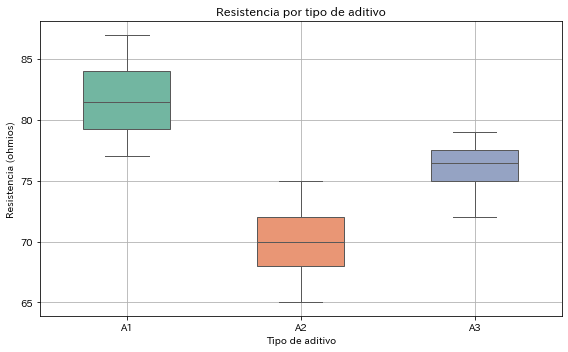

```python
chart = BoxChart2(df0, x='Aditivo', y='Resistencia', hue='Aditivo', title="Resistencia por tipo de aditivo", xlabel="Tipo de aditivo", ylabel="Resistencia (ohmios)")
fig = chart.box_chart2()

plt.show()
```

Paso 2: Cálculo de la suma de cuadrados

$ SST = 408.9 $

$ SSA = 276.2 $

$ SSE = 132.7 $

Paso 3: Cálculo de los grados de libertad

$ \phi_T = 11 $

$ \phi_A = 2 $

$ \phi_E = 9 $

Paso 4: Creación de la tabla ANOVA

```python
df
```

| Factor | r1 | r2 | r3 | r4 | total | total^2 |
| --- | --- | --- | --- | --- | --- | --- |
| A1 | 87.0 | 77.0 | 83.0 | 80.0 | 327.0 | 106929.0 |
| A2 | 71.0 | 75.0 | 65.0 | 69.0 | 280.0 | 78400.0 |
| A3 | 72.0 | 77.0 | 76.0 | 79.0 | 304.0 | 92416.0 |
| total | 230.0 | 229.0 | 224.0 | 228.0 | 911.0 | 277745.0 |

```python
anova = Anova00(df0, a=1, b=1)
anova_table = anova.creacion_ANOVA()
display(anova_table)
print(message)
```

[output not shown]

[output not shown]

```python
anova_tabla, message = creacion_ANOVA(df0, a=1, b=1)
display(anova_tabla.round(2))
print(message)
```

|  | Suma de cuadrados (SS) | Grado de libertad (df) | Suma de cuadrados (MS) | Valor F |
| --- | --- | --- | --- | --- |
| Entre grupos | 276.17 | 2 | 138.083333 | 9.362 |
| Error | 132.75 | 9 | 14.75 |  |
| Total | 408.92 | 11 |  |  |

```
=== Prueba de significacia ===
Valor crítical del 5% de la distribución F (2, 9) = 4.256
Valor F obervado = 9.362
Valor p = 0.006
⇒ Se rechaza la hipótesis nula: existe una diferencia significativa entre los niveles.

=== Media poblacional de cada nivel y su intervalo de confianza del 95% ===
A1: Estimación puntual = 81.75, 95% CI = (76.73, 86.77)
A2: Estimación puntual = 70.00, 95% CI = (64.98, 75.02)
A3: Estimación puntual = 76.00, 95% CI = (70.98, 81.02)
```

```python
data = dict0(df0)
bartlett_levene(data)
```

```
🔎 バートレット検定:
  統計量 = 0.4114, p値 = 0.8141
➡️ 正規性があるなら p < 0.05 で分散に有意差あり

🔎 レビーン検定:
  統計量 = 0.3962, p値 = 0.6840
➡️ p < 0.05 なら分散に有意差あり（より頑健）
```

```
{'bartlett': {'statistic': np.float64(0.4113976649692243),
  'pvalue': np.float64(0.8140782132802427)},
 'levene': {'statistic': np.float64(0.39622641509433965),
  'pvalue': np.float64(0.6840370027405092)}}
```

```python
data = df0.to_dict()
records = []
for rep, cond_dict in data.items():
    for factor, value in cond_dict.items():
        records.append({'Aditivo': factor, 'Resistencia': value})

df_ = pd.DataFrame(records)

# 分散分析（ANOVA）
model = ols('Resistencia ~ C(Aditivo)', data=df_).fit()
anova_table = sm.stats.anova_lm(model, typ=1)

print("\n【分散分析表 (ANOVA)】")
display(anova_table.round(2))
```

```
【分散分析表 (ANOVA)】
```

|  | df | sum_sq | mean_sq | F | PR(>F) |
| --- | --- | --- | --- | --- | --- |
| C(Aditivo) | 2.0 | 276.17 | 138.08 | 9.36 | 0.01 |
| Residual | 9.0 | 132.75 | 14.75 | NaN | NaN |

Paso 5: Decisión

$ F_0 = 9.37 > F(2,9:0.01) = 8.02 $

Es altamente **significativo** al 1% de nivel de significancia. Se puede afirmar que el tipo de aditivo está influyendo en la resistencia del conductor.

```python
df_anova = pd.DataFrame(anova_table )

dfA = df_anova.loc["C(Aditivo)","df"]
dfE = df_anova.loc["Residual","df"]

F = df_anova.loc["C(Aditivo)","F"]

alpha = 0.01  # 有意水準

# 有意性検定（F分布の上側1%点と比較）
F_crit = stats.f.ppf(1 - alpha, dfA, dfE)
p_value = 1 - stats.f.cdf(F, dfA, dfE)

print(f'If F: {F:.2f} > F_crit ({alpha}) :{F_crit:.2f}\n')

if F > F_crit:
    print("⇒ Se rechaza la hipótesis nula: existe una diferencia significativa entre los niveles.")
else:
    print("⇒ No se puede rechazar la hipótesis nula: no existe una diferencia significativa entre los niveles.")
```

```
If F: 9.36 > F_crit (0.01) :8.02

⇒ Se rechaza la hipótesis nula: existe una diferencia significativa entre los niveles.
```

## 7.2

家庭用プラスチック製品Pにおいて、強度（単位：MPa）が重要な特性である。強度に大きく影響をあたえると思われる要因として、２種類の原価剤QとRの混合比を取り上げ、実験を行うこととした。混合比を要因Aとして４水準設定し、繰り返し５回、計２０回の実験をランダムに行い、表７．９のデータを得た。ただし、A4水準の実験ではトラブルが発生し４個のデータしか得られなかった。２種類の添加剤の混合比QとRは、A1がQ：R=8：２，A2が７：３，A3が６：４，A4が５：５である。分散分析を行い、要因効果の有無を検証せよ。また、現行条件はA1である。最適条件と現行条件との母平均の差を推定せよ。

En el producto doméstico de plástico P, la resistencia (unidad: MPa) es una característica importante. Se decidió realizar un experimento considerando como factor el porcentaje de mezcla de dos aditivos principales, Q y R, ya que se piensa que esta influye significativamente en la resistencia. Se establecieron cuatro niveles para el factor A (la proporción de mezcla), y se llevaron a cabo 20 experimentos en total, con cinco repeticiones para cada nivel, de forma aleatoria. Sin embargo, en el nivel A4 ocurrió un problema y solo se obtuvieron cuatro datos. Las proporciones de mezcla de los aditivos Q y R son las siguientes: A1 = Q:R = 8:2, A2 = 7:3, A3 = 6:4, y A4 = 5:5. Realiza un análisis de varianza (ANOVA) para verificar si el factor tiene un efecto significativo. Además, considerando que la condición actual es A1, estima la diferencia entre la media poblacional bajo la condición óptima y la condición actual.

```python
# スプレッドシートを開く（URLまたはスプレッドシートIDを使用）
SPREADSHEET_ID = "1Ma7ehT4TAnkUwJjspP-C3mwJA1hYmbJr8B9GJSFI0lU"
sheet = client.open_by_key(SPREADSHEET_ID).worksheet("Sheet18") # 最初のシートを取得

# データを取得
list_of_lists = sheet.get_all_records()
df = pd.DataFrame(list_of_lists)

df = df.set_index("Factor")
df.iloc[3:4,4:5] = np.nan
df = df.apply(pd.to_numeric, errors='coerce')

df0 = df.copy()
data = df0.to_dict()

df['total'] = df.sum(axis=1)
df['total^2'] = df['total']**2
df.loc['total'] = df.sum()

df.to_excel("./Data2/Data_7_1.xlsx",index=False)

print("Tabla 7.7")
df
```

```
Tabla 7.7
```

| Factor | r1 | r2 | r3 | r4 | r5 | total | total^2 |
| --- | --- | --- | --- | --- | --- | --- | --- |
| A1 | 30.0 | 35.0 | 38.0 | 31.0 | 37.0 | 171.0 | 29241.0 |
| A2 | 34.0 | 39.0 | 37.0 | 38.0 | 35.0 | 183.0 | 33489.0 |
| A3 | 40.0 | 37.0 | 45.0 | 42.0 | 39.0 | 203.0 | 41209.0 |
| A4 | 38.0 | 36.0 | 41.0 | 37.0 | NaN | 152.0 | 23104.0 |
| total | 142.0 | 147.0 | 161.0 | 148.0 | 111.0 | 709.0 | 127043.0 |

Paso 1: Modelo de la estructura de datos

$ x_{ij} = \mu + a_i + \epsilon_{ij} $

$ \sum r_l a_i = 5 a_1 + 5 a_2 + 5 a_3 + 4 a_4 = 0 $

$ \epsilon_{ij} \sim N(0, \sigma^2) $

Paso 2: Graficación del los datos.

El nivel A3 parece tener la mayor resistencia, pero los datos están dispersos.

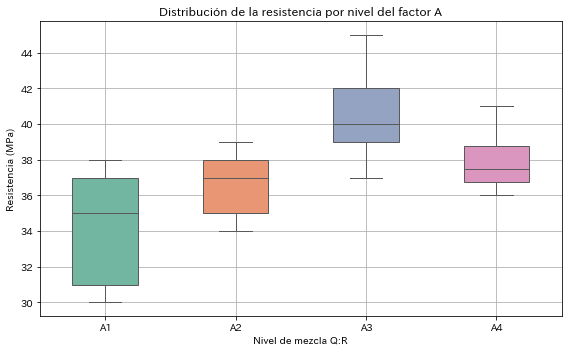

```python
chart = BoxChart2(df0, x='Nivel', y='Resistencia', hue='Nivel', title="Distribución de la resistencia por nivel del factor A", xlabel="Nivel de mezcla Q:R", ylabel="Resistencia (MPa)")
fig = chart.box_chart2()

plt.show()
```

Paso 4: Cálculo de la suma de cuadrados

$ SST = 226.11 $

$ SSA = 106.91 $

$ SSE = 119.20 $

Paso 5: Cálculo de los grados de libertad

$ \phi_T = 18 $

$ \phi_A = 3 $

$ \phi_E = 15 $

Paso 6: Creación de la tabla ANOVA

```python
def creacion_ANOVA2(df):
    # 平均を水準（行）ごとに計算
    means = df.mean(axis=1, skipna=True)
    overall_mean = df.stack().mean()

    # 各要素数（有効な観測値）
    ni = df.count(axis=1)

    # 群間平方和 (SSB)
    SSB = sum(ni * (means - overall_mean) ** 2)

    # 群内平方和 (SSW)
    SSW = sum(((df.sub(means, axis=0)) ** 2).sum(axis=1, skipna=True))

    # 総平方和 (SST)
    SST = sum((df.stack() - overall_mean) ** 2)

    # 自由度
    a = len(df)               # 水準数
    n = df.count().sum()      # 有効な全観測数
    df_total = n - 1
    df_between = a - 1
    df_within = df_total - df_between

    # 平均平方
    MSB = SSB / df_between
    MSW = SSW / df_within

    # F値
    F = MSB / MSW

    # 分散分析表を作成
    anova_table = pd.DataFrame({
        '自由度': [df_between, df_within, df_total],
        '平方和': [SSB, SSW, SST],
        '平均平方': [MSB, MSW, ''],
        'F値': [F, '', '']
    }, index=['群間', '群内', '全体'])

    # 結果表示
    pd.set_option('display.precision', 4)
    print("🔍 一元配置分散分析表（手動計算）\n")

    return anova_table
```

```python
anova_table, message = creacion_ANOVA(df0, a=1, b=0)
display(anova_table)
print(message)
```

|  | Suma de cuadrados (SS) | Grado de libertad (df) | Suma de cuadrados (MS) | Valor F |
| --- | --- | --- | --- | --- |
| Entre grupos | 106.905263 | 3 | 35.635088 | 4.484 |
| Error | 119.200000 | 15 | 7.946667 |  |
| Total | 226.105263 | 18 |  |  |

```
=== Prueba de significacia ===
Valor crítical del 5% de la distribución F (3, 15) = 3.287
Valor F obervado = 4.484
Valor p = 0.019
⇒ Se rechaza la hipótesis nula: existe una diferencia significativa entre los niveles.
```

```python
df_raw = pd.DataFrame(df0.to_dict())
df_long = df_raw.melt(var_name='Repeticion', value_name='Resistencia', ignore_index=False)
df_long = df_long.reset_index().rename(columns={'index': 'Nivel'})

# Ejecución del ANOVA
df_long = df_long.dropna()
model = ols('Resistencia ~ C(Nivel)', data=df_long).fit()
anova_table = sm.stats.anova_lm(model, typ=1)

# Estimación de la diferencia entre la media poblacional de la condición óptima
# y la del nivel A1
means = df_long.groupby('Nivel')['Resistencia'].mean()
optimal_level = means.idxmax()
mean_difference = means[optimal_level] - means['A1']

print("Nivel con la mayor resistencia: ", optimal_level)

# ANOVA
df = pd.DataFrame(anova_table)
print("\n【ANOVA】")
display(df.round(2))
```

```
Nivel con la mayor resistencia:  A3

【ANOVA】
```

|  | df | sum_sq | mean_sq | F | PR(>F) |
| --- | --- | --- | --- | --- | --- |
| C(Nivel) | 3.0 | 106.91 | 35.64 | 4.48 | 0.02 |
| Residual | 15.0 | 119.20 | 7.95 | NaN | NaN |

Paso 7: Decisión

Se puede decir que es significancia estadística con un nivel de 5%

```python
# Grados de libertad
dfn = 3  # Grados de libertad del numerador
dfd = 15  # Grados de libertad del denominador

# Nivel de significancia
alpha = 0.01
alpha2 = 0.05

# Punto 1% superior de la distribución F,
# Punto 5% superior de la distribución F,
f_critical = stats.f.ppf(1 - alpha, dfn, dfd)
f_critical2 = stats.f.ppf(1 - alpha2, dfn, dfd)

print(f"Punto del {alpha*100:.0f}% superior en la distribucón F(dfn={dfn}, dfd={dfd}) : {f_critical:.2f}")
print(f"Punto del {alpha2*100:.0f}% superior en la distribución F(dfn={dfn}, dfd={dfd}) : {f_critical2:.2f}")
```

```
Punto del 1% superior en la distribucón F(dfn=3, dfd=15) : 5.42
Punto del 5% superior en la distribución F(dfn=3, dfd=15) : 3.29
```

Paso 8: Modelo de estructura de datos después del ANOVO

$ x_{ij} = \mu + a_i + \epsilon_{ij}$

Paso 9: Estimación de la media poblacional en el nivel de mayor poblacional

1. Estimación puntual de la media poblacional
- $ \hat{x}(A_3) = \bar{x}_{3*} = 40.6 $ (MPa)
1. Estimación por intervalo de la media poblacional (95% de confianza)
- $ \hat{x}(A_3) \pm t(\phi, \alpha) \sqrt{V_E / r_3} = 40.6 \pm t(15, 0.05) \sqrt{7.95 / 5} = [ 37.9, 43.3] $
1. Estimar la diferencia de las medias poblacionales entre la condición óptima A3 y condición actual A1.
- $ \hat{\mu} (A_i) - \hat{\mu} (A_{i'}) = \bar{x_{i*}} - \bar{x_{i'*}} $
- $ \hat{\mu} (A_3) - \hat{\mu} (A_1) = \bar{x}_{3*} - \bar{x}_{1*} = 6.4 $ (MPa)
1. Estimación por intervalo de la diferencia de medias poblacionales.
- $ \hat{\mu}(A_i) - \hat{\mu} (A_{i'}) \pm t(\phi_E, \alpha) \sqrt{(1/r_i + 1/r_{i'}) V_E} $
- $ \hat{\mu}(A_3) - \hat{\mu} (A_{1}) \pm t(\phi_E, \alpha) \sqrt{(1/r_3 + 1/r_{1}) V_E} = 6.4 \pm t(15, 0.05) \times \sqrt{(1/5 + 1/5) \times 7.95} = [2.6, 10.2] $

```python
from scipy import stats

# Data (A1, A3)
data_A1 = df_long[df_long['Nivel'] == 'A1']['Resistencia']
data_max = df_long[df_long['Nivel'] == optimal_level]['Resistencia']

# Número de data (A1, A3)
n3 = len(data_max)
n1 = len(data_A1)

# Diferencia de medias poblacionales
mean_diff = data_max.mean() - data_A1.mean()

# Suma de cuadrados del residuo y grados de libertad (del ANOVA)
SSE = df.loc["Residual","sum_sq"]
df_residual = df.loc["Residual", "df"]
MSE = SSE / df_residual  # Media cuadrática del residuo

# Error estándar y valor t
se = np.sqrt(MSE / n3)
t_critical = stats.t.ppf(1 - 0.05/2, df=df_residual)

# Cálculo del intervalo de confianza
margin_of_error = t_critical * se
ci_lower = data_max.mean() - margin_of_error
ci_upper = data_max.mean() + margin_of_error

# Estimación del intervalo de confianza para la diferencia de medias
se2 = np.sqrt(MSE*(1/n3+1/n1))
margin_of_error2 = t_critical * se2
ci_lower2 = mean_diff - margin_of_error2
ci_upper2 = mean_diff + margin_of_error2

#
print(f"Media del nivel con la mayor resistencia:{optimal_level}: {data_max.mean():.1f}")
print(f"Intervalo de confianza del 95%: [{ci_lower:.1f}, {ci_upper:.1f}]")
print(f"\nMedia del nivel actual A1: {data_A1.mean():.1f}")
print(f"\nDiferencia de medias de A1 y A3 : {mean_diff:.1f}")
print(f"Estimación por intervalo de la diferencia de medias: [{ci_lower2:.1f}, {ci_upper2:.1f}]")
```

```
Media del nivel con la mayor resistencia:A3: 40.6
Intervalo de confianza del 95%: [37.9, 43.3]

Media del nivel actual A1: 34.2

Diferencia de medias de A1 y A3 : 6.4
Estimación por intervalo de la diferencia de medias: [2.6, 10.2]
```

```python
df_anova = pd.DataFrame(anova_table )

dfA = df_anova.loc["C(Nivel)","df"]
dfE = df_anova.loc["Residual","df"]

F = df_anova.loc["C(Nivel)","F"]

alpha = 0.05  # Nivel de significancia

# Prueba de significancia
#  (comparación con el punto superior del 5% de la distribución F)
F_crit = stats.f.ppf(1 - alpha, dfA, dfE)
p_value = 1 - stats.f.cdf(F, dfA, dfE)

print(f'If F: {F:.2f} > F_crit ({alpha}) :{F_crit:.2f}\n')

if F > F_crit:
    print("⇒ Se rechaza la hipótesis nula: existe una diferencia significativa entre los niveles.")
else:
    print("⇒ No se puede rechazar la hipótesis nula: no existe una diferencia significativa entre los niveles.")
```

```
If F: 4.48 > F_crit (0.05) :3.29

⇒ Se rechaza la hipótesis nula: existe una diferencia significativa entre los niveles.
```

## 07-03 Experimento factorial de dos factores

２元配置実験

### 1. ¿Qué es un experimento factorial de dos factores?

二元配置実験とは

Un experimento factorial de dos factores consiste en considerar dos factores: el factor A con los niveles y el factor B con m niveles, realizando experimentos en todas las combinaciones posibles de niveles de ambos factores, es decir en l x m condiciones.

Un diseño en el que se realiza un solo experimento por cada combinación de niveles se denomina experimento factorial de dos factores sin repetición, mientras que un diseño en el que se realizan múltiples repeticiones por cada combinación se denomina experimento factorial de dos factores con repetición.

### 2. Formato de datos de un experimento factorial de dos vectores

二元配置実験のデータ形式

- Formato de datos obtenido en un experimento factorial de dos factores con replicación

[Audio_7](https://drive.google.com/file/d/1P8BJSkDURaclU5L6wPUc-TE74TsiN8J3/view?usp=drive_link)

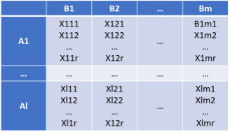

```python
from PIL import Image

img = Image.open('./Data2/7-12.png')
display(img)
```

- Formato de datos obtenido en un experimento factorial de dos factores sin replicación
  - No es posible comprobar la existencia o ausencia de interacción

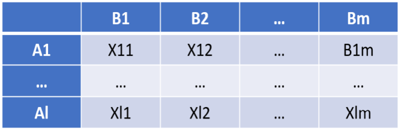

```python
img = Image.open('./Data2/7-13.png')

resized_img = img.resize((400, 130))
display(resized_img)
```

### 3. Procedimiento do análisis de un experimento factorial de dos factores con repeticiones

くり返しのある二元配置実験の解析手順

Un experimento que toma dos factores y realiza múltiples repeticiones para todos las combinaciones de los niveles de ambos factores se denomina "**experimento factorial de dos vías con repeticiones**". Este tipo de experimento ofrece las siguientes ventajas en comparación con un experimento factorial de dos vías sin repeticiones.

1. Se puede determinar el efecto de interacción.
2. Se pueden separar el término de error y la interacción.
3. Se puede verificar la homocedasticidad del error a partir de los datos de las repeticiones.

#### (1) Ecuación estructural de los datos

データの構造式

- $ x_{ijk} = \mu + a_i + b_j + (ab)_{ij} + \epsilon_{ijk}$
- $ \mu $: Media general
- $ a_i $: Efecto principal del factor A ($ i = 1,2,..., l) $)
- $ b_j $: Efecto principal del factor B ($ j = 1,2,..., m) $)
- $ (ab)_{ij} $: Efecto de interacción entre A y B
- $ \epsilon_{ijk} $: Error($ k = 1, 2, ..., r $)

#### (2) Efectos principales e interacciones

主効果と交互作用効果

Los datos obtenidos en un experimento a veces muestran, además de los efectos individuales de los factores estudiados (efectos principales) y la influencia del entorno experimental (error), el efecto de la combinación de los factores. Cuando el efecto del factor B cambia según el nivel del factor A, decimos que existe una "interacción" entre el factor A y el factor B. A este impacto resultante de la combinación de factores se le denomina "efecto de interacción AxB".

#### (3) Descomposición de la variación y cálculo de las sumas de cuadrados

バラツキの分解と平方和の計算

#### (4) Elaboración de la tabla de análisis de varianza

分散分析表の作成

#### (5) Consideración sobre el pooling

プーリングについての検討

En la tabla de análisis de varianza, si la interacción AxB no es significativa y el valor $ F_0 $ es pequeño y se considera despreciable, la suma de cuadrados de la interacción ($ S_{A \times B} $) se puede "poolear" con la suma de cuadrados del error ($ S_E $) para formar una nueva $ S_E $.

#### (6) Estimación cuando la interacción AxB no puede ser ignorada

交互作用が無視できない場合の推定

1. Fórmula del modelo de los datos después del análisis de varianza.
- $ x_{ijk} = \mu + a_i + b_j + (ab)_{ij} + \epsilon_{ijk} $
1. Determinación del nivel óptimo
- Determinar comparando los valores promedio de los niveles $ A_i B_j $ ($ \bar{x}_{ij*} $)
1. Estimación puntual de la media poblacional.
- $ \hat{\mu}(A_i B_j) = \hat{\mu + a_i + b_j + (ab)_{ij}} = \bar{x}_{ij*} $
1. Estimación por intervalo de la media poblacional.
- $ \hat{\mu} (A_i B_j) \pm t(\phi_E, \alpha) \sqrt{V_E / r} $

[Audio_8](https://drive.google.com/file/d/1daUmfBVEZBoR4j7cPEnp6Z06SV2TsXpX/view?usp=drive_link)

1. Fórmula del modelo de los datos después del análisis de varianza.
- $ x_{ijk} = \mu + a_i + b_j + \epsilon_{ijk} $
1. Determinación del nivel óptimo
- Determinar comparando los valores promedio de los niveles $ A_i B_j $ ($ \bar{x}_{ij*} $)
1. Estimación puntual de la media poblacional.
- $ \hat{\mu}(A_i B_j) = \hat{\mu + a_i + b_j} = \hat{\mu + a_i} + \hat{\mu + b_j} - \hat{\mu} = \bar{x}_{i**} + \bar{x}_{*j*} - \bar{\bar{x}} $
1. Estimación por intervalo de la media poblacional.
- $ \hat{\mu} (A_i B_j) \pm t(\phi_{E'}, \alpha) \sqrt{V_{E'} / n_{\epsilon}} $
- $ \phi_{E'} $, $ V_{E'} $ se obtienen de la tabla ANOVA después del pooling. $ n_e $ es el **número efectivo** de repeticiones, y existen fórmulas para calcularlo, como la **fórmula de Taguchi** y la **fórmula de Ina**.

[Audio_9](https://drive.google.com/file/d/1Cn2tBEtDigVWndUq6p0Ov_BRgMw_xp6g/view?usp=drive_link)

## 7.3

機能性フィルム製品Qにおいて、フィルム張り合わせ時の接着特性（剥離強度）を高めるために、製造条件を改善することになった。A因子：硬化剤比率（２水準）、B因子：加熱温度（４水準）で繰り返し２回、計１６回の実験をランダムに行い表７．１７のデータを得た。値は大きい方が望ましい。分散分析を行い、要因効果の有無を検討するとともに、最適条件での母平均の点推定と区間推定（信頼率９５％）を行え。

En el producto de película funcional QUE, se decidió mejorar las condiciones de fabricación para aumentar las propiedades adhesivas (resistencia al desprendimiento) durante la laminación de las películas. Se realizaron 16 experimentos aleatorios con dos repeticiones para cada combinación de los siguientes factores:

Factor A: Proporción de endurecedor (2 niveles)

Factor B: temperatura de calentamiento (4 niveles)

Se obtuvieron los datos de la Tabla 7.17. Se desea que los valores sean lo más altos posible.

Realice un análisis de varianza (ANOVA) para examinar si los factores tienen efectos significativos, y estime el valor medio poblacional bajo las condiciones óptimas, proporcionando tanto la estimación puntual como el intervalo de confianza al 95%.

Paso 1: Ecuación estructural de los datos

- $ x_{ijk} = \mu + a_i + b_j + (ab)_{ij} + \epsilon_{ijk}$

```python
# スプレッドシートを開く（URLまたはスプレッドシートIDを使用）
SPREADSHEET_ID = "1Ma7ehT4TAnkUwJjspP-C3mwJA1hYmbJr8B9GJSFI0lU"
sheet = client.open_by_key(SPREADSHEET_ID).worksheet("Sheet19") # 最初のシートを取得

# データを取得
list_of_lists = sheet.get_all_records()
df = pd.DataFrame(list_of_lists)

df = df.set_index("A")
df0 = df.copy()

data_dict = df.to_dict()

# 辞書を整形してDataFrameへ
records = []
for b, a_dict in data_dict.items():
    for a, val in a_dict.items():
        a_level = a[:2]  # A11, A12 → A1 など
        rep = a[2:]      # A11, A12 → 1, 2 など
        records.append({
            'A': a_level,
            'B': b,
            'Rep': int(rep),
            'Value': float(val)
        })

print("Tabla 7.17")
df
```

```
Tabla 7.17
```

| A | B1 | B2 | B3 | B4 |
| --- | --- | --- | --- | --- |
| A11 | 3 | 4 | 12 | 10 |
| A12 | 6 | 7 | 16 | 9 |
| A21 | 13 | 17 | 13 | 1 |
| A22 | 9 | 18 | 11 | 5 |

```python
df1 = pd.DataFrame(records)
df1
```

|  | A | B | Rep | Value |
| --- | --- | --- | --- | --- |
| 0 | A1 | B1 | 1 | 3.0 |
| 1 | A1 | B1 | 2 | 6.0 |
| 2 | A2 | B1 | 1 | 13.0 |
| 3 | A2 | B1 | 2 | 9.0 |
| 4 | A1 | B2 | 1 | 4.0 |
| 5 | A1 | B2 | 2 | 7.0 |
| 6 | A2 | B2 | 1 | 17.0 |
| 7 | A2 | B2 | 2 | 18.0 |
| 8 | A1 | B3 | 1 | 12.0 |
| 9 | A1 | B3 | 2 | 16.0 |
| 10 | A2 | B3 | 1 | 13.0 |
| 11 | A2 | B3 | 2 | 11.0 |
| 12 | A1 | B4 | 1 | 10.0 |
| 13 | A1 | B4 | 2 | 9.0 |
| 14 | A2 | B4 | 1 | 1.0 |
| 15 | A2 | B4 | 2 | 5.0 |

Paso 2: Graficación de datos

Es probable que haya un efecto de A y también un efecto de B.

Es probable que haya una interacción AxB.

```python
df0
```

| A | B1 | B2 | B3 | B4 |
| --- | --- | --- | --- | --- |
| A11 | 3 | 4 | 12 | 10 |
| A12 | 6 | 7 | 16 | 9 |
| A21 | 13 | 17 | 13 | 1 |
| A22 | 9 | 18 | 11 | 5 |

```
     B1  B2  B3  B4
A
A11   3   4  12  10
A12   6   7  16   9
A21  13  17  13   1
A22   9  18  11   5
```

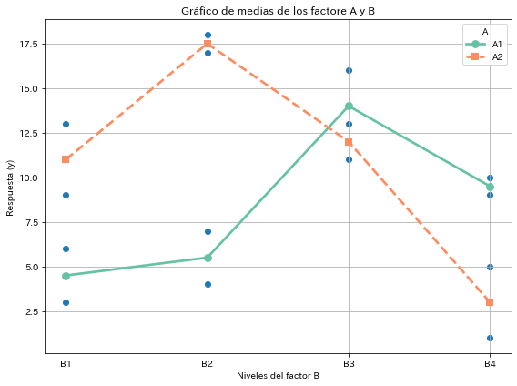

```python
from chart import PointChart # type: ignore

chart = PointChart(df0, x="B", y="Value", hue="A",
                   title="Gráfico de medias de los factore A y B",
                   xlabel="Niveles del factor B", ylabel="Respuesta (y)")
fig = chart.plot()
plt.show()
```

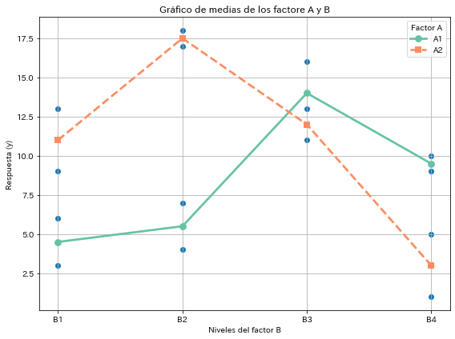

```python
df = pd.DataFrame(records)

# 平均値プロット
plt.figure(figsize=(8, 6))
sns.pointplot(x="B", y="Value", hue="A", data=df,
              markers=["o", "s"], linestyles=["-", "--"],
              palette="Set2", dodge=False, errorbar=None)
plt.scatter(df["B"],df["Value"])
plt.title("Gráfico de medias de los factore A y B")
plt.ylabel("Respuesta (y)")
plt.xlabel("Niveles del factor B")
plt.grid(True)
plt.legend(title="Factor A")
plt.tight_layout()
plt.show()
```

Paso 4: Cálculo de la suma de cuadrados

$ SST = 387.75 $

$ SSA = 25.00 $

$ SSB = 119.25 $

$ SSA:B = 207.50 $

$ SSE = 36.00 $

Paso 5: Cálculo de los grados de libertad

$ \phi_T = 15 $

$ \phi_A = 1 $

$ \phi_B = 3 $

$ \phi_{A:B} = 3 $

$ \phi_E = 8 $

Paso 6: Creación de la tabla ANOVA

```python
def creacion_Anova3(records):

    df = pd.DataFrame(records)
    display(df)

    # AとBの水準数を取得
    ll = sorted(set(d['A'] for d in records))
    mm = sorted(set(d['B'] for d in records))

    # A×Bごとの繰り返し数を取得
    rr = defaultdict(set)
    for d in records:
        key = (d['A'], d['B'])
        rr[key].add(d['Rep'])

    l = len(ll)
    m = len(mm)
    r = len(rr[key])

    print(f'l:{l} m:{m} r:{r}\n')

    # 総平均
    grand_mean = df['Value'].mean()

    # 総平方和（SST）
    sst = ((df['Value'] - grand_mean)**2).sum()

    print(f'SST: {sst:.2f}')

    # 因子Aの水準（A11, A12, A21, A22）
    a_means = df.groupby('A')['Value'].mean()
    ssa = sum(df.groupby('A').size() * (a_means - grand_mean) ** 2)
    print(f'SSA: {ssa:.2f}')

    # 因子Bの水準（B1〜B4）
    b_means = df.groupby('B')['Value'].mean()
    ssb = sum(df.groupby('B').size() * (b_means - grand_mean) ** 2)
    print(f'SSB: {ssb:.2f}')

    # A平均・B平均・交互作用平均の準備
    ab_means = df.groupby(['A', 'B'])['Value'].mean()

    # 交互作用平方和の計算
    ssab = 0
    for (a, b), ab_mean in ab_means.items():
        a_mean = a_means[a]
        b_mean = b_means[b]
        ssab += (ab_mean - a_mean - b_mean + grand_mean) ** 2
    ssab *= r  # 各セルの繰り返し

    print(f'SSAB: {ssab:.2f}')

    # 誤差平方和（SSE）
    sse = sst - ssa - ssb - ssab
    print(f'SSE: {sse:.2f}')

    # 自由度
    df_a = l - 1
    df_b = m - 1
    df_ab = df_a * df_b
    df_e = len(df) - l*m

    print(f'DF_A: {df_a}  DF_B: {df_b}  DF_AB: {df_ab}  DF_E: {df_e}')

    # 平均平方
    msa = ssa / df_a
    msb = ssb / df_b
    msab = ssab / df_ab
    mse = sse / df_e if df_e != 0 else np.nan

    # 分散分析表の作成
    anova_table = pd.DataFrame({
        'sum_sq': [ssa, ssb, ssab, sse, sst],
        'df': [df_a, df_b, df_ab, df_e, len(df)-1],
        'mean_sq': [msa, msb, msab, mse, ''],
        'F': [msa/mse if mse else np.nan,
                msb/mse if mse else np.nan,
                msab/mse if mse else np.nan,
                '', '']
    }, index=['A', 'B', 'AxB', 'Residual', 'Total'])

    print("\nANOVA:")
    display(anova_table)


creacion_Anova3(records)
```

|  | A | B | Rep | Value |
| --- | --- | --- | --- | --- |
| 0 | A1 | B1 | 1 | 3.0 |
| 1 | A1 | B1 | 2 | 6.0 |
| 2 | A2 | B1 | 1 | 13.0 |
| 3 | A2 | B1 | 2 | 9.0 |
| 4 | A1 | B2 | 1 | 4.0 |
| 5 | A1 | B2 | 2 | 7.0 |
| 6 | A2 | B2 | 1 | 17.0 |
| 7 | A2 | B2 | 2 | 18.0 |
| 8 | A1 | B3 | 1 | 12.0 |
| 9 | A1 | B3 | 2 | 16.0 |
| 10 | A2 | B3 | 1 | 13.0 |
| 11 | A2 | B3 | 2 | 11.0 |
| 12 | A1 | B4 | 1 | 10.0 |
| 13 | A1 | B4 | 2 | 9.0 |
| 14 | A2 | B4 | 1 | 1.0 |
| 15 | A2 | B4 | 2 | 5.0 |

```
l:2 m:4 r:2

SST: 387.75
SSA: 25.00
SSB: 119.25
SSAB: 207.50
SSE: 36.00
DF_A: 1  DF_B: 3  DF_AB: 3  DF_E: 8

ANOVA:
```

|  | sum_sq | df | mean_sq | F |
| --- | --- | --- | --- | --- |
| A | 25.00 | 1 | 25.0 | 5.555556 |
| B | 119.25 | 3 | 39.75 | 8.833333 |
| AxB | 207.50 | 3 | 69.166667 | 15.37037 |
| Residual | 36.00 | 8 | 4.5 |  |
| Total | 387.75 | 15 |  |  |

```python
import anova # type: ignore
importlib.reload(anova)

from anova import Anova3 # type: ignore

anova = Anova3(df0)
anova_table3, message = anova.creacion_Anova3()

print(message)
display(anova_table3)
```

```
l:2 m:4 r:2
SST: 387.75
SSA: 25.00
SSB: 119.25
SSAB: 207.50
SSE: 36.00
DF_A: 1  DF_B: 3  DF_AB: 3  DF_E: 8

【Optimal Condition】
Aの最適条件: A2 Bの最適条件: B2 最大のValue: 17.5
Optimal Mean: 17.50
95% Confidence Interval: [14.040993797193751, 20.95900620280625]
```

|  | sum_sq | df | mean_sq | F | PR(>F) |
| --- | --- | --- | --- | --- | --- |
| A | 25.00 | 1 | 25.000000 | 5.555556 | 0.046172 |
| B | 119.25 | 3 | 39.750000 | 8.833333 | 0.006420 |
| AxB | 207.50 | 3 | 69.166667 | 15.370370 | 0.001104 |
| Residual | 36.00 | 8 | 4.500000 | NaN | NaN |
| Total | 387.75 | 15 | NaN | NaN | NaN |

```python
df = pd.DataFrame(records)

# Construcción de model para ANOVA
model = ols('Value ~ C(A) * C(B)', data=df).fit()
anova_table = sm.stats.anova_lm(model, typ=1)

print("\n【ANOVA】")
print(anova_table)
```

```
【ANOVA】
            df  sum_sq    mean_sq          F    PR(>F)
C(A)       1.0   25.00  25.000000   5.555556  0.046172
C(B)       3.0  119.25  39.750000   8.833333  0.006420
C(A):C(B)  3.0  207.50  69.166667  15.370370  0.001104
Residual   8.0   36.00   4.500000        NaN       NaN
```

Paso 7: Coclusión

A y B son significativos al 5% de nivel de significancia, y AxB es significativo al 1% de nivel de significancia. Es decir, la proporción del agente endurecedor, la temperatura de calentamiento y la interacción entre ambos influyen en la resistencia al desprendimiento.

Paso 8: Fórmula del modelo de los datos después del análisis de varianza.

$ x_{ijk} = \mu + a_i + b_j + (ab)_{ij} + \epsilon_{ijk}$

Paso 9: Estimación de la media poblacional en el nivel con mayor fuerza de adhesión.

La condición de combinación máxima es el nivel A2B2.

Estimación puntual de la media poblacional: 17.5

Estimación por intervalo de la media poblacional (con un nivel de confianza del 95%): [14.0 21.0]

```python
# Determinar las condiciones óptimas (con el valor meio máximo)
means = df.groupby(['A', 'B'])['Value'].mean().reset_index()
optimal_condition = means.loc[means['Value'].idxmax()]
optimal_mean = optimal_condition['Value']

# Extracción de los datos bajo las condiciones óptimas
opt_data = df[(df['A'] == optimal_condition['A']) & (df['B'] == optimal_condition['B'])]['Value']
mean = np.mean(opt_data)

df2 = pd.DataFrame(anova_table)

# Suma de cuadrados del residuo y grados de libertad (del ANOVA)
SSE = df2.loc["Residual","sum_sq"]
df_residual = df2.loc["Residual", "df"]
MSE = SSE / df_residual  # Media cuadrática del residuo

n = 2 #　Número de repeticiones
se = np.sqrt(MSE / n)
t_critical = stats.t.ppf(1 - 0.05/2, df=df_residual)

# Cálculo del intervalo de confianza
margin_of_error = t_critical * se
ci_lower = optimal_mean - margin_of_error
ci_upper = optimal_mean + margin_of_error

print("\n【Optimal Condition】")
print(optimal_condition)
print(f"\nOptimal Mean: {optimal_mean:.2f}")

print(f"95% Confidence Interval: [{ci_lower:.1f}, {ci_upper:.1f}]")
```

```
【Optimal Condition】
A          A2
B          B2
Value    17.5
Name: 5, dtype: object

Optimal Mean: 17.50
95% Confidence Interval: [14.0, 21.0]
```

## 7.4

アルミ製品Rにおいて、コスト低減のために導入したプレス穴加工機でのダレ量が大きく問題になっている。そこでA因子：パンチの形状（４水準）、B因子：穴あけ順序（３水準）で繰り返し２回の実験をランダムに行い表7.22のデータを得た。値は小さい方が望ましい。分散分析を行い、プーリングの有無を検討するとともに、最適条件での母平均の点推定と区間推定（信頼率９５％）を行え。

En el producto de aluminio R, la cantidad de rebaba generada por la prensa perforadora introducida para reducir costos se ha convertido en un problema importante.

Se realizaron experimentos aleatorios dos repeticiones para cada combinación de los siguientes factores:

Factor A: forma del punzón (4 niveles)

Factor B: orden de perforación (3 niveles)

Se obtuvieron los datos de la Tabla 7.22. Se desea que los valores sean lo más pequeños posible.

Realice un análisis de varianza (ANOVA), examine la necesidad de hacer pooling (agrupación) y estime la media poblacional bajo las condiciones óptimas, proporcionando tanto la estimación puntual como el intervalo de confianza al 95%.

```python
# スプレッドシートを開く（URLまたはスプレッドシートIDを使用）
SPREADSHEET_ID = "1Ma7ehT4TAnkUwJjspP-C3mwJA1hYmbJr8B9GJSFI0lU"
sheet = client.open_by_key(SPREADSHEET_ID).worksheet("Sheet20") # 最初のシートを取得

# データを取得
list_of_lists = sheet.get_all_records()
df = pd.DataFrame(list_of_lists)

df = df.set_index("A")

df0 = df.copy()

data_dict = df.to_dict()

# 辞書を整形してDataFrameへ
records = []
for b, a_dict in data_dict.items():
    for a, val in a_dict.items():
        a_level = a[:2]  # A11, A12 → A1 など
        rep = a[2:]      # A11, A12 → 1, 2 など
        records.append({
            'A': a_level,
            'B': b,
            'Rep': int(rep),
            'Value': float(val)
        })

print("Tabla 7.22")
df
```

```
Tabla 7.22
```

| A | B1 | B2 | B3 |
| --- | --- | --- | --- |
| A11 | 4.8 | 3.5 | 3.7 |
| A12 | 4.2 | 3.2 | 3.9 |
| A21 | 3.8 | 3.0 | 3.6 |
| A22 | 4.4 | 3.2 | 3.1 |
| A31 | 5.2 | 4.2 | 3.9 |
| A32 | 5.7 | 3.4 | 3.3 |
| A41 | 4.6 | 3.4 | 3.9 |
| A42 | 3.9 | 3.0 | 3.7 |

Paso 1: Graficación de datos

Ambos efectos, A y B, parecen estar presentes. No parece haber interacción.

```
      B1   B2   B3
A
A11  4.8  3.5  3.7
A12  4.2  3.2  3.9
A21  3.8  3.0  3.6
A22  4.4  3.2  3.1
A31  5.2  4.2  3.9
A32  5.7  3.4  3.3
A41  4.6  3.4  3.9
A42  3.9  3.0  3.7
```

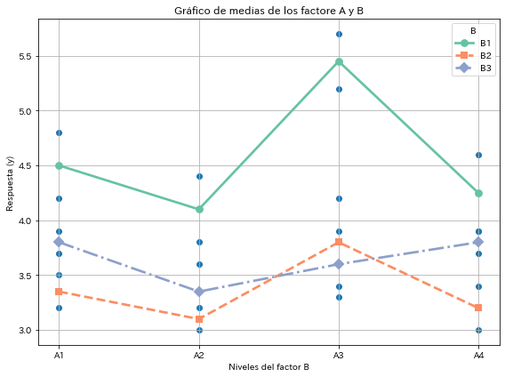

```python
chart = PointChart(df0, x="A", y="Value", hue="B",
                   title="Gráfico de medias de los factore A y B",
                   xlabel="Niveles del factor B", ylabel="Respuesta (y)")
fig = chart.plot()
plt.show()
```

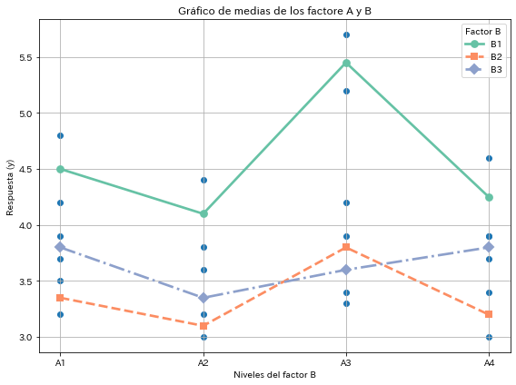

```python
df = pd.DataFrame(records)

# 平均値プロット
plt.figure(figsize=(8, 6))

sns.pointplot(x="A", y="Value", hue="B", data=df,
              palette="Set2", dodge=False, errorbar=None,
              markers=["o", "s", "D"], linestyles=["-", "--", "-."])

plt.scatter(x=df["A"],y=df["Value"])
plt.title("Gráfico de medias de los factore A y B")
plt.ylabel("Respuesta (y)")
plt.xlabel("Niveles del factor B")
plt.grid(True)
plt.legend(title="Factor B")
plt.tight_layout()
plt.show()
```

Paso 2: Se creó la tabla ANOVA con la varianza agrupada

Al realizar la prueba para la interacción AxB, el valor F (F0) fue de 1.55, lo cual no es significativo al nivel de significancia del 5%. Dado que la interacción AxB no es significativa y el valor F0 es pequeño y puede considerarse despreciable, la suma de cuadrados de la interacción ($ S_{A \times B} $) se agrupa con el error estándar ($ S_E $) para formar un nuevo error estándar ($ S_{E'} $). Con estos datos, se crea la tabla ANOVA.

```python
creacion_Anova3(records)
```

|  | A | B | Rep | Value |
| --- | --- | --- | --- | --- |
| 0 | A1 | B1 | 1 | 4.8 |
| 1 | A1 | B1 | 2 | 4.2 |
| 2 | A2 | B1 | 1 | 3.8 |
| 3 | A2 | B1 | 2 | 4.4 |
| 4 | A3 | B1 | 1 | 5.2 |
| 5 | A3 | B1 | 2 | 5.7 |
| 6 | A4 | B1 | 1 | 4.6 |
| 7 | A4 | B1 | 2 | 3.9 |
| 8 | A1 | B2 | 1 | 3.5 |
| 9 | A1 | B2 | 2 | 3.2 |
| 10 | A2 | B2 | 1 | 3.0 |
| 11 | A2 | B2 | 2 | 3.2 |
| 12 | A3 | B2 | 1 | 4.2 |
| 13 | A3 | B2 | 2 | 3.4 |
| 14 | A4 | B2 | 1 | 3.4 |
| 15 | A4 | B2 | 2 | 3.0 |
| 16 | A1 | B3 | 1 | 3.7 |
| 17 | A1 | B3 | 2 | 3.9 |
| 18 | A2 | B3 | 1 | 3.6 |
| 19 | A2 | B3 | 2 | 3.1 |
| 20 | A3 | B3 | 1 | 3.9 |
| 21 | A3 | B3 | 2 | 3.3 |
| 22 | A4 | B3 | 1 | 3.9 |
| 23 | A4 | B3 | 2 | 3.7 |

```
l:4 m:3 r:2

SST: 11.06
SSA: 1.86
SSB: 6.47
SSAB: 1.19
SSE: 1.54
DF_A: 3  DF_B: 2  DF_AB: 6  DF_E: 12

ANOVA:
```

|  | sum_sq | df | mean_sq | F |
| --- | --- | --- | --- | --- |
| A | 1.858333 | 3 | 0.619444 | 4.82684 |
| B | 6.465833 | 2 | 3.232917 | 25.191558 |
| AxB | 1.194167 | 6 | 0.199028 | 1.550866 |
| Residual | 1.540000 | 12 | 0.128333 |  |
| Total | 11.058333 | 23 |  |  |

```python
df_d = pd.DataFrame(records)

# Construcción de modelo para ANOVA
model = ols('Value ~ C(A) * C(B)', data=df_d).fit()
anova_table = sm.stats.anova_lm(model, typ=2)

print("\n【ANOVA】")
print(anova_table)

df = pd.DataFrame(anova_table)
anova_dict = df.to_dict()
```

```
【ANOVA】
             sum_sq    df          F    PR(>F)
C(A)       1.858333   3.0   4.826840  0.019841
C(B)       6.465833   2.0  25.191558  0.000051
C(A):C(B)  1.194167   6.0   1.550866  0.243498
Residual   1.540000  12.0        NaN       NaN
```

```python
import anova # type: ignore
importlib.reload(anova)
from anova import Anova33 # type: ignore

anova = Anova33(df0, min=1, p=1)
message, anova_table = anova.creacion_Anova33()

print(message)
display(anova_table)
```

```
l: 4  m: 3  r: 2
SST: 11.06
SSA: 1.86
SSB: 6.47
SSAB: 1.19
SSE: 1.54

※ Elementos a grupar：AxB
Número efectivo de repeticiones (n_e): 0.250

【Estimación del valor medio poblacional bajo la condición óptima y su IC 95%】
● Condición óptimal: A = A2, B = B2
● Estimación puntual (promedio mínimo): 3.02
● Intervalo de confianza del 95%: (nan, nan)
```

| Source | sum_sq | df | mean_sq | F | PR(>F) |
| --- | --- | --- | --- | --- | --- |
| A | 1.858333 | 3 | 0.619444 | 4.078025 | 0.022525 |
| B | 6.465833 | 2 | 3.232917 | 21.283450 | 0.000018 |
| Residual | 2.734167 | 18 | 0.151898 | NaN | NaN |

```python
# Elementos a agrupar（p > 0.05）
pool_terms = [term for term, pval in anova_dict['PR(>F)'].items() if pval > 0.05]

# Inicialización
pooled_ss = anova_dict['sum_sq']['Residual']
pooled_df = anova_dict['df']['Residual']

# Sumar los elementos agrupados al Residual
for term in pool_terms:
    if term != 'Residual':  #
        pooled_ss += anova_dict['sum_sq'][term]
        pooled_df += anova_dict['df'][term]

# Calucular el cuadrado medio（Mean Square）
pooled_ms = pooled_ss / pooled_df

# Crear una nueva table ANOVA （despues del agrupamiento）
anova_pooled = {
    'Source': [],
    'SS': [],
    'df': [],
    'MS': [],
    'F': [],
    'p-value': []
}

for term in ['C(A)', 'C(B)']:
    ss_ = anova_dict['sum_sq'][term]
    df = anova_dict['df'][term]
    ms = ss_ / df
    f_val = ms / pooled_ms
    p_val = stats.f.sf(f_val, df, pooled_df)
    anova_pooled['Source'].append(term)
    anova_pooled['SS'].append(ss_)
    anova_pooled['df'].append(df)
    anova_pooled['MS'].append(ms)
    anova_pooled['F'].append(f_val)
    anova_pooled['p-value'].append(p_val)

# Residual（después del agrupamiento）
anova_pooled['Source'].append('Residual (pooled)')
anova_pooled['SS'].append(pooled_ss)
anova_pooled['df'].append(pooled_df)
anova_pooled['MS'].append(pooled_ms)
anova_pooled['F'].append(None)
anova_pooled['p-value'].append(None)

# Tabla
anova_df = pd.DataFrame(anova_pooled)
print("【Tabla ANOVA después del agrupamiento】")
print(anova_df.round(4))
print(f"\n※ Elementos a grupar：{', '.join(pool_terms)}")
```

```
【Tabla ANOVA después del agrupamiento】
              Source      SS    df      MS        F  p-value
0               C(A)  1.8583   3.0  0.6194   4.0780   0.0225
1               C(B)  6.4658   2.0  3.2329  21.2835   0.0000
2  Residual (pooled)  2.7342  18.0  0.1519      NaN      NaN

※ Elementos a grupar：C(A):C(B)
```

Paso 3: Conclusión de los resultados

El factor A es significativo al nivel del 5%, y el factor B es significativo al nivel del 1%. Esto significa que tanto la forma del punzón como la secuencia de perforación tienen un efecto en la cantidad de rebaba.

Paso 4: Fórmula de la estructura de los datos después del análisis de varianza.

- Nota: La condición de combinación mínima se considera sin interacción.
  - $ \hat{\mu} = \hat{(\mu + a_2)} + \hat{(\mu + b_2)} - \hat{\mu}$

Paso 5: Estimación de la media poblacional en el nivel con menor rebaba.

```python
# Calcular el promedio por condición
mean_table = df_d.groupby(["A", "B"])["Value"].mean().reset_index()

# AとBの平均、全体平均を計算
A_means = df_d.groupby('A')['Value'].mean()
B_means = df_d.groupby('B')['Value'].mean()
grand_mean = df_d['Value'].mean()

# Encontrar la condición con el valor más bajo（＝condición óptima）
optimal_row = mean_table.loc[mean_table["Value"].idxmin()]
optimal_condition = (optimal_row["A"], optimal_row["B"])

a_min = optimal_row['A']
b_min = optimal_row['B']
mu_min = A_means[a_min] + B_means[b_min] - grand_mean

# --- Número efectivo de repeticiones（fómula de Ina） ---
n_a = df_d[df_d["A"] == a_min].shape[0]
n_b = df_d[df_d["B"] == b_min].shape[0]
r_eff = 1 / ((1 / n_a) + (1 / n_b) - (1 / len(df_d)))
print(f"Número efectivo de repeticiones (n_e): {1 / r_eff:.3f}\n")

# Cálculo del intervalo de confianza
MSE = anova_df.iloc[2,3]  # 0.1519
r = r_eff  #
df_error = anova_df.iloc[2,2] # 18
t_val = stats.t.ppf(1 - 0.05 / 2, df_error)

margin = t_val * np.sqrt(MSE / r)
ci_lower = mu_min - margin
ci_upper = mu_min + margin

# 結果出力
print("【Estimación del valor medio poblacional bajo la condición óptima y su IC 95%】")
print(f"● Condición óptimal: A = {optimal_condition[0]}, B = {optimal_condition[1]}")
print(f"● Estimación puntual (promedio mínimo): {mu_min:.2f}")
print(f"● Intervalo de confianza del 95%: ({ci_lower:.2f}, {ci_upper:.2f})")
```

```
Número efectivo de repeticiones (n_e): 0.250

【Estimación del valor medio poblacional bajo la condición óptima y su IC 95%】
● Condición óptimal: A = A2, B = B2
● Estimación puntual (promedio mínimo): 3.02
● Intervalo de confianza del 95%: (2.61, 3.43)
```

### 4. Procedimiento para el análisis de un experimento factorial de dos factores sin replicación

くり返しのない２元配置実験

Se le llama "experimento factorial de dos vías sin repeticiones" aquel en el que se toman dos factores y se realiza el experimento una sola vez para cada una de las combinaciones posibles de los niveles de ambos factores, sin repetición.

#### (1) Estructura del modelo de datos

データの構造式

$ x_{ij} = \mu + a_i + b_j + \epsilon_{ij} $

$ \mu $: Media general

$ a_i $: Efecto principal del Factor A ($ i = 1, 2, ..., l $)

$ b_j $: Efecto principal del Factor B ($ j = 1,2, ..., m $)

$ \epsilon_{ij} $ Error

#### (2) Efectos principales e interacción

主効果と交互作用

En un experimento factorial de dos vías sin repeticiones, la suma total de cuadrados se descompone únicamente en la suma de cuadrados de los efectos principales y la suma de cuadrados del error. Aunque exista interacción, su efecto se confunde (o enmascara) con el error y no puede separarse. Por lo tanto, no es posible detectar la presencia de interacción. Un experimento factorial de dos vías sin repeticiones solo debe aplicarse cuando se tiene la certeza de que no existe interacción.

#### (3) Descomposición de la variabilidad y cálculo de la suma de cuadrados

ばらつきの分解と平方和の計算

$ S_T = S_A + S_B + S_E $

#### (4) Elaboración de la tabla de análisis de varianza (ANOVA)

分散分析表の作成

#### (5) Estimación del valor medio poblacional según la combinación de condiciones

組み合わせ条件による母平均の推定

Número efectivo de repeticiones: Existen la fórmula de Taguchi y la fórmula de Ina.

Fórmula de Taguchi: $ \frac{1}{n_e} = \frac{1 + (Suma　de　los　grados　de　libertad　de　los　factores　usados　en　la　estimación　puntual)}{Número　total　de　datos} $

Fórmula de Ina: $ \frac{1}{n_e} = $ Suma de los coeficientes de las medias utilizados en la estimación puntual

[Audio_10](https://drive.google.com/file/d/135qIO21aqDyWXnzx34yWb57TLp_aa_00/view?usp=drive_link)

#### (6) Procedimiento del análisis de varianza (ANOVA) para un experimento factorial de dos factores sin replicación

くり返しのない二元配置実験の分散分析手順

[Audio_11](https://drive.google.com/file/d/1WJBhv7Cgx2vIeX8jQ0j6h0epHqiQTJg2/view?usp=drive_link)

## 7.5

特殊レンズの透過性を向上させるため、A：添加物の種類、B：燒結温度を各３水準にとって、すべての水準組み合わせで１回ずつ、計９回の実験をランダムな順序で行った。実験の結果得られた特定波長での透過率（％）のデータを表７．２８に示す。分散分析を行い、各要因の効果を検討せよ。そして、この実験条件のうちで等価性を最も高められ条件での透過性の母平均を信頼性９５％で推定せよ。

Con el fin de mejorar la transmitancia de una lente especial, se realizaron experimentos tomando como factores A: tipo de aditivo y B: temperatura de sinterización, ambos con 3 niveles. Se llevaron a cabo una vez cada combinación de niveles, en un orden aleatorio, para un total de 9 experimentos. Los datos obtenidos de la transmitancia (%) en una longitud de onda específica se presentan en la Tabla 7.28.

Realice un análisis de varianza (ANOVA) y examine el efecto de cada factor. Luego, estime el valor medio poblacional de la transmitancia con un nivel de confianza del 95% bajo la condición experimental que maximiza la equivalencia óptica.

```python
# スプレッドシートを開く（URLまたはスプレッドシートIDを使用）
SPREADSHEET_ID = "1Ma7ehT4TAnkUwJjspP-C3mwJA1hYmbJr8B9GJSFI0lU"
sheet = client.open_by_key(SPREADSHEET_ID).worksheet("Sheet21") # 最初のシートを取得

# データを取得
list_of_lists = sheet.get_all_records()
df = pd.DataFrame(list_of_lists)
df = df.set_index("A")

df0 = df.copy()

data_dict = df.to_dict()

# データを縦長（tidy）形式に変換
data = []
for B, row in data_dict.items():
    for A, value in row.items():
        data.append({'A': A, 'B': B, 'Value': float(value)})

print("Tabla 7.28")
display(df)
```

```
Tabla 7.28
```

| A | B1 | B2 | B3 |
| --- | --- | --- | --- |
| A1 | 12 | 11 | 8 |
| A2 | 10 | 8 | 4 |
| A3 | 6 | 7 | 5 |

Paso 1: Fórmula de la estructura de los datos

$ x_{ij} = \mu + a_i + b_j + \epsilon_{ij} $

Paso 2: Graficación de los datos

- Parece que hay efectos tanto de A como de B.
- Sin embargo, no parece haber interacción.

```
    B1  B2  B3
A
A1  12  11   8
A2  10   8   4
A3   6   7   5
```

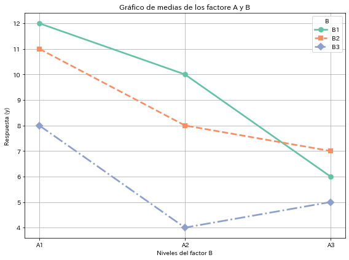

```python
from chart import PointChart # type: ignore

chart = PointChart(df0, x="A", y="Value", hue="B",
                   title="Gráfico de medias de los factore A y B",
                   xlabel="Niveles del factor B", ylabel="Respuesta (y)")
fig = chart.plot()
plt.show()
```

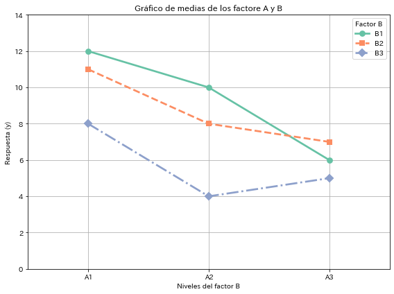

```python
df = pd.DataFrame(data)

# 平均値プロット
plt.figure(figsize=(8, 6))

sns.pointplot(x="A", y="Value", hue="B", data=df,
              palette="Set2", dodge=False, errorbar=None,
              markers=["o", "s", "D"], linestyles=["-", "--", "-."])

plt.ylim(0,14)
plt.title("Gráfico de medias de los factore A y B")
plt.ylabel("Respuesta (y)")
plt.xlabel("Niveles del factor B")
plt.grid(True)
plt.legend(title="Factor B")
plt.tight_layout()
plt.show()
```

Paso 4: Cálculo de la suma de cuadrados

Paso 5: Cálculo de los grados de libertad

Paso 6: Creación de la tabla de análisis de varianza (ANOVA)

```python
import anova # type: ignore
importlib.reload(anova)
from anova import Anova4 # type: ignore

anova = Anova4(df0, min=0)
anova_table4, message = anova.creacion_Anova4()

display(anova_table4)
print(message)
```

|  | sum_sq | df | mean_sq | F | PR(>F) |
| --- | --- | --- | --- | --- | --- |
| A | 29.555556 | 2 | 14.777778 | 9.172414 | 0.032045 |
| B | 22.888889 | 2 | 11.444444 | 7.103448 | 0.048267 |
| Residual | 6.444444 | 4 | 1.611111 | NaN | NaN |
| Total | 58.888889 | 8 |  | NaN | NaN |

```
SST: 58.89
SSA: 29.56
SSB: 22.89
SSE: 6.44
DF_A: 2  DF_B: 2  DF_E: 4

【Condicion óptima】 A=A1, B=B1 → 透過率 = 11.78

【Número efectivo de repeticiones fórmula de Ina】: 1.800

【Estimación puntual 】: 11.78
【Intervalo de confianza del 95%】: (9.15, 14.40)
```

```python
df = pd.DataFrame(data)

# ANOVA
model = ols('Value ~ C(A) + C(B)', data=df).fit()
anova_table = sm.stats.anova_lm(model, typ=2)
print("【ANOVA】")
print(anova_table)
```

```
【ANOVA】
             sum_sq   df         F    PR(>F)
C(A)      29.555556  2.0  9.172414  0.032045
C(B)      22.888889  2.0  7.103448  0.048267
Residual   6.444444  4.0       NaN       NaN
```

Paso 7: Decisión

$ F_0 = 9.18 > F(2,4:0.05) = 6.94 $

A, B son significativos al nivel de significancia del 5%

Paso 8: Estimación de la media poblacional en el nivel con la mayor transmitancia

```python
# Calcular las medias de A y B y la media global
A_means = df.groupby('A')['Value'].mean()
B_means = df.groupby('B')['Value'].mean()
grand_mean = df['Value'].mean()

# Calcular el promedio por condición
mean_table = df.pivot_table(index='A', columns='B', values='Value')

# Encontrar la condición con el promedio más alto
best_condition = df.loc[df['Value'].idxmax()]

a_max = best_condition['A']
b_max = best_condition['B']
mu_max = A_means['A1'] + B_means['B1'] - grand_mean

print(f"\n【Condicion óptima】 A={a_max}, B={b_max} → 透過率 = {mu_max:.2f}")

# Grados de libertad y cuadrado medio residual
MS_error = anova_table.loc['Residual', 'sum_sq'] / anova_table.loc['Residual', 'df']
df_error = anova_table.loc['Residual', 'df']

# Número efectivo de repeticiones fórmula de Ina：1 / (1/a + 1/b - 1/N)）
a = df['A'].nunique()
b = df['B'].nunique()
n_effective = 1 / (1/a + 1/b - 1/len(df))
print(f"\n【Número efectivo de repeticiones fórmula de Ina】: {n_effective:.3f}")

# Cálcuro de Intervalo de confianza del 95%
t_val = stats.t.ppf(0.975, df_error)
margin_error = t_val * np.sqrt(MS_error / n_effective)
mean_estimate = best_condition['Value']
ci_lower = mu_max - margin_error
ci_upper = mu_max + margin_error

print(f"\n【Estimación puntual 】: {mu_max:.2f}")
print(f"【Intervalo de confianza del 95%】: ({ci_lower:.2f}, {ci_upper:.2f})")
```

```
【Condicion óptima】 A=A1, B=B1 → 透過率 = 11.78

【Número efectivo de repeticiones fórmula de Ina】: 1.800

【Estimación puntual 】: 11.78
【Intervalo de confianza del 95%】: (9.15, 14.40)
```

## Por favor, responda a las preguntas del examen de práctica a través del siguiente enlace.

[Simulacro de examne](https://forms.gle/Zb5mqXMe3LfqQMER8)

## 14.3

因子Aを４水準に設定し、繰り返し４回の一元配置実験をランダムな順序でおこなって、表１４．１の結果を得た。分散分析を行い、各水準の母平均の点推定と９５％区間推定を行え。

Se estableció el factor A en cuatro niveles y se realizó un experimento de clasificación única con cuatro repeticiones en orden aleatorio, obteniéndose los resultados de la Tabla 14.1. Realice un análisis de varianza y obtenga la estimación puntual y el intervalo de confianza del 95% para la media poblacional de cada nivel.

```python
# スプレッドシートを開く（URLまたはスプレッドシートIDを使用）
SPREADSHEET_ID = "1Ma7ehT4TAnkUwJjspP-C3mwJA1hYmbJr8B9GJSFI0lU"
sheet = client.open_by_key(SPREADSHEET_ID).worksheet("Sheet25") # 最初のシートを取得

# データを取得
list_of_lists = sheet.get_all_records()
df = pd.DataFrame(list_of_lists)

df['r'] = df.groupby('Nivel').cumcount()+1

df_wide = df.pivot(index="r", columns="Nivel", values="Valor")
df0 = df_wide.T.copy()
df0 = df0.astype(float)

display(df_wide)
```

| Nivel r | A1 | A2 | A3 | A4 |
| --- | --- | --- | --- | --- |
| 1 | 2 | 6 | 8 | 3 |
| 2 | 4 | 5 | 6 | 4 |
| 3 | 3 | 3 | 7 | 5 |
| 4 | 5 | 4 | 5 | 2 |

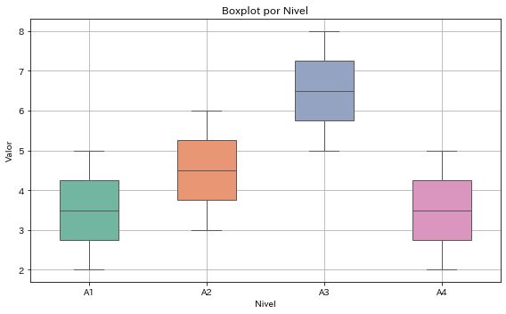

```python
chart = BoxChart2(df0, x='Nivel', y='Valor', hue='Nivel', title="Boxplot por Nivel", xlabel="", ylabel="")
fig = chart.box_chart2()

plt.show()
```

```python
import anova # type: ignore
importlib.reload(anova)
from anova import Anova # type: ignore

anova = Anova(df, min=2)
anova_table4, message = anova.creacion_Anova()

display(anova_table4)
print(message)
```

| Source | df | sum_sq | mean_sq | F | PR(>F) |
| --- | --- | --- | --- | --- | --- |
| A | 3 | 24.0 | 8.000000 | 4.8 | 0.020188 |
| Residual | 12 | 20.0 | 1.666667 | NaN | NaN |
| Total | 15 | 44.0 | NaN | NaN | NaN |

```
SSA: 24.00
SSE: 20.00
DF_A: 3.00
DF_E: 12.00

【Estimación puntual de la media poblacional para cada nivel】
Nivel
A1    3.5
A2    4.5
A3    6.5
A4    3.5
【Intervalo de confianza del 95% para cada nivel】
A1: 3.50 ± 1.41 → CI = [2.09, 4.91]
A2: 4.50 ± 1.41 → CI = [3.09, 5.91]
A3: 6.50 ± 1.41 → CI = [5.09, 7.91]
A4: 3.50 ± 1.41 → CI = [2.09, 4.91]
```

```python
# Análisis de Varianza de un Factor
model = smf.ols('Valor ~ C(Nivel)', data=df).fit()
anova_table = sm.stats.anova_lm(model, typ=2)

anova_table
```

|  | sum_sq | df | F | PR(>F) |
| --- | --- | --- | --- | --- |
| C(Nivel) | 24.0 | 3.0 | 4.8 | 0.020188 |
| Residual | 20.0 | 12.0 | NaN | NaN |

## 14.4

因子Aを４水準、繰り返し４回の一元配置実験をランダムな順序で行い、表１４．２のような結果を得た。下記を行え。

1. 分散分析
2. A３水準の母平均の点推定と、９５％区間推定
3. A1とA3の母平均の差の点推定と９５％区間推定

Se fijó el factor A en cuatro niveles y se realizó un experimento de clasificación única con cuatro repeticiones en orden aleatorio, obteniéndose los resultados mostrados en la Tabla 14.2. Realice lo siguiente.

1. Análisis de varianza.
2. Estimación puntual y el intervalo de confianza del 95% para la media poblacional del nivel A3.
3. Estimación puntual y el intervalo de confianza del 95% para la diferencia de las medias poblacionales entre los niveles A1 y A3.

```python
# スプレッドシートを開く（URLまたはスプレッドシートIDを使用）
SPREADSHEET_ID = "1Ma7ehT4TAnkUwJjspP-C3mwJA1hYmbJr8B9GJSFI0lU"
sheet = client.open_by_key(SPREADSHEET_ID).worksheet("Sheet30") # 最初のシートを取得

# データを取得

list_of_lists = sheet.get_all_records()
df = pd.DataFrame(list_of_lists)

df_wide = df.pivot(index="r", columns="Nivel", values="Valor")
display(df_wide)
```

| Nivel r | A1 | A2 | A3 | A4 |
| --- | --- | --- | --- | --- |
| 1 | 2.0 | 7.0 | 8.0 | 4.0 |
| 2 | 4.0 | 6.0 | 6.0 | 5.0 |
| 3 | 3.0 | 4.0 | 7.0 | 6.0 |
| 4 | 5.0 | 5.0 | NaN | 3.0 |

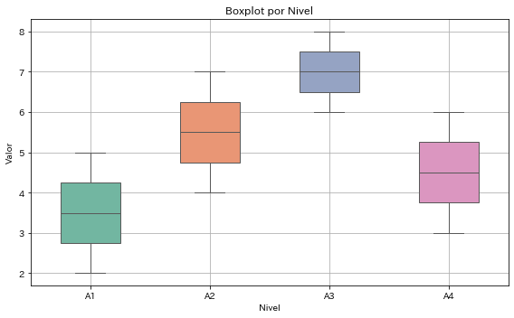

```python
chart = BoxChart2(df_wide.T, x='Nivel', y='Valor', hue='Nivel', title="Boxplot por Nivel", xlabel="", ylabel="")
fig = chart.box_chart2()

plt.show()
```

```python
import anova # type: ignore
importlib.reload(anova)
from anova import Anova # type: ignore

anova = Anova(df, min=1)
anova_table4, message = anova.creacion_Anova()
display(anova_table4)
print(message)
```

| Source | df | sum_sq | mean_sq | F | PR(>F) |
| --- | --- | --- | --- | --- | --- |
| A | 3 | 23.0 | 7.666667 | 4.960784 | 0.020395 |
| Residual | 11 | 17.0 | 1.545455 | NaN | NaN |
| Total | 14 | 40.0 | NaN | NaN | NaN |

```
SSA: 23.00
SSE: 17.00
DF_A: 3.00
DF_E: 11.00

【2. Media poblacional de A3】
  Estimación puntual: 7.00
  Intervalo de confianza del 95%: [5.42, 8.58]
【3. Deferencia de medidas poblacionales (A3 - A1) 】
  Estimación puntual: 3.50
  Intervalo de confianza del 95%: [1.41, 5.59]
```

```python
# Valores faltantes
df_clean = df.dropna()

model = smf.ols('Valor ~ C(Nivel)', data=df_clean).fit()
anova_table = sm.stats.anova_lm(model, typ=2)
print(anova_table)
```

```
          sum_sq    df         F    PR(>F)
C(Nivel)    23.0   3.0  4.960784  0.020395
Residual    17.0  11.0       NaN       NaN
```

## 14.5

因子A, Bの特性値への影響の有無を検証するために、因子Aについて２水準、因子Bについて４水準の繰り返しなしの二元配置実験をランダムな順序で行い表１４．３を得た。次を行え。

1. 分散分析表の作成
2. 第２水準における因子Aの効果 $ \hat{a}_2 $の推定
3. 因子Aの第一水準、第２水準における効果の推定値 $ \hat{a}_1 $、 $ \hat{a}_2 $ の平均平方 $ V_A $ の期待値
4. 第２水準における因子Bの効果 $ \hat{b}_2 $の推定値
5. 因子Aが第２水準、因子Bが第２水準における実験誤差 $ \epsilon_{22} $ の推定

Para verificar la presencia o ausencia de influencia de los factores A y B en los valores característicos, se llevó a cabo un experimento factorial de dos vías sin repetición en orden aleatorio, con dos niveles para factor A y cuatro niveles para el factor B, obteniéndose los resultados mostrados en la Tabla 14.3. Realice lo siguiente:

1. Elaboración de la tabla de análisis de varianza.
2. Estimación del efecto del factor A en el segundo nivel $ \hat{a}_2 $.
3. Estimación de los efectos del factor A en el primer y segundo nivel $ \hat{a}_1 $ y $ \hat{a}_2 $ y el valor esperado del cuadrado medio de A, $ V_A $.
4. Estimación del efecto del factor B en el segundo nivel $ \hat{b}_2 $.
5. Estimación del error experimental $ \epsilon_{22} $ cuando el factor A está en el segundo nivel y el factor B está en el segundo nivel.

```python
# スプレッドシートを開く（URLまたはスプレッドシートIDを使用）
SPREADSHEET_ID = "1Ma7ehT4TAnkUwJjspP-C3mwJA1hYmbJr8B9GJSFI0lU"
sheet = client.open_by_key(SPREADSHEET_ID).worksheet("Sheet31") # 最初のシートを取得

# データを取得
list_of_lists = sheet.get_all_records()
df = pd.DataFrame(list_of_lists)

df_wide = df.pivot(index="A", columns="B", values="Value")
df_wide
```

| B A | B1 | B2 | B3 | B4 |
| --- | --- | --- | --- | --- |
| A1 | 6 | 10 | 8 | 4 |
| A2 | 8 | 12 | 12 | 8 |

```python
import anova # type: ignore
importlib.reload(anova)
from anova import Anova4 # type: ignore

anova = Anova4(df_wide, min=1)
anova_table4, message = anova.creacion_Anova4()

display(anova_table4)
print(message)
```

|  | sum_sq | df | mean_sq | F | PR(>F) |
| --- | --- | --- | --- | --- | --- |
| A | 18.0 | 1 | 18.0 | 27.0 | 0.013847 |
| B | 34.0 | 3 | 11.333333 | 17.0 | 0.021856 |
| Residual | 2.0 | 3 | 0.666667 | NaN | NaN |
| Total | 54.0 | 7 |  | NaN | NaN |

```
SST: 54.00
SSA: 18.00
SSB: 34.00
SSE: 2.00
DF_A: 1  DF_B: 3  DF_E: 3

【Estimación del efecto del facotr A】
a^1 (Estimación del efecto de A1): -1.5
a^2 (Estimación del erecto de A2): 1.5

【Valor esperado del cuadrado medio del factor A (VA)】
VA = 18.00

【EStimación del efecto del segundo nivel B2 del factor B】
b^2 = 2.5

【Estimación del error ε22 】
ε22 = -0.5
```

```
B   B1  B2  B3  B4
A
A1   6  10   8   4
A2   8  12  12   8
```

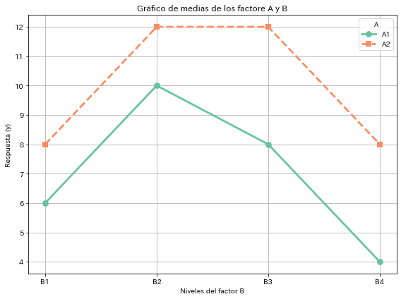

```python
chart = PointChart(df_wide, x="B", y="Value", hue="A",
                   title="Gráfico de medias de los factore A y B",
                   xlabel="Niveles del factor B", ylabel="Respuesta (y)")
fig = chart.plot()
plt.show()
```

```python
# Elaboración del modelo de análisis de varianza
model = ols('Value ~ C(A) + C(B)', data=df).fit()
anova_table = sm.stats.anova_lm(model, typ=2)
print("【ANOVA】")
print(anova_table)
```

```
【ANOVA】
          sum_sq   df     F    PR(>F)
C(A)        18.0  1.0  27.0  0.013847
C(B)        34.0  3.0  17.0  0.021856
Residual     2.0  3.0   NaN       NaN
```

La estructura del modelo de datos:

$ x_{ij} = \mu + a_i + b_j + \epsilon_{ij} $

Un experimento factorial de dos factores sin repetición se utiliza cuando no hay interacción.

```
【Estimación del efecto del facotr A】
a^1 (Estimación del efecto de A1): -1.5
a^2 (Estimación del erecto de A2): 1.5

【Valor esperado del cuadrado medio del factor A (VA)】
VA = 18.00

【EStimación del efecto del segundo nivel B2 del factor B】
b^2 = 2.5

【Estimación del error ε22 】
ε22 = -0.5
```

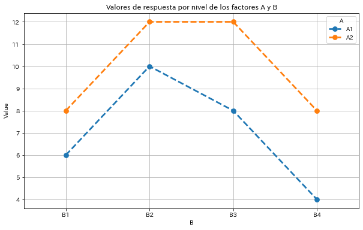

```python
# Estimación del efecto de cada ninvel
grand_mean = df['Value'].mean()
a1_mean = df[df['A'] == 'A1']['Value'].mean()
a2_mean = df[df['A'] == 'A2']['Value'].mean()
a1 = a1_mean - grand_mean
a2 = a2_mean - grand_mean

print("\n【Estimación del efecto del facotr A】")
print(f"a^1 (Estimación del efecto de A1): {a1}")
print(f"a^2 (Estimación del erecto de A2): {a2}")

# Suma de cuadrados y cuadrados medios
SSA = anova_table.loc['C(A)', 'sum_sq']
VA = SSA / anova_table.loc['C(A)', 'df']

print(f"\n【Valor esperado del cuadrado medio del factor A (VA)】\nVA = {VA:.2f}")

# Estimación del efecto del segundo nivel B2 del factor B
b2_mean = df[df['B'] == 'B2']['Value'].mean()
b2 = b2_mean - grand_mean
print(f"\n【EStimación del efecto del segundo nivel B2 del factor B】")
print(f"b^2 = {b2}")

# Estimación del error experimental ε22
epsilon_22 = df[(df['A'] == 'A2') & (df['B'] == 'B2')]['Value'].values[0] - grand_mean - a2 - b2
print(f"\n【Estimación del error ε22 】")
print(f"ε22 = {epsilon_22}")

#
plt.figure(figsize=(10, 6))
sns.pointplot(data=df, x='B', y='Value', hue='A', markers='o', linestyles='--')
plt.title("Valores de respuesta por nivel de los factores A y B")
plt.grid(True)
plt.show()
```

## 14.6

## 14.6

因子A、Bの特性値への有無を検証するために、因子Aについて２水準、因子Bについて４水準、繰り返し２回の二元配置実験をlランダムな順序で行い、グラフ化した。各区ラフについて、因子A、Bの主効果および交互作用AxBの存在を推測せよ。

Para verificar la presencia o asusencia de los efectos de los factores A y B en los valores caracteriscicos, se llevó a cabo un experimento factorial de dos vías con 2 niveles para el factor A, 4 niveles para el factor B y 2 repeticiones en orden aleatorio, y se grafcicaron los resultados. Para cada gráfico, infiere la presencia de los efectos principales de los factores A y B, y la interacción.

```python
# スプレッドシートを開く（URLまたはスプレッドシートIDを使用）
SPREADSHEET_ID = "1W4H3VxXJwpKGMu0rE9ocz6yA6J0boG9vGzktgsro1es"
sheet = client.open_by_key(SPREADSHEET_ID).worksheet("Sheet4") # 最初のシートを取得

# データを取得
list_of_lists = sheet.get_all_records()
df = pd.DataFrame(list_of_lists)
```

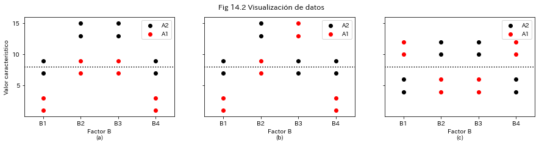

```python
x = df['Level']
y1 = df["Value1"]
y11 = df['Value11']

y2 = df['Value2']
y22 = df['Value22']

y3 = df['Value3']
y33 = df['Value33']


fig, ax = plt.subplots(ncols=3, sharex=True, sharey=True,figsize=(15,3))

ax[0].scatter(x,y1,color='k', label="A2")
ax[0].scatter(x,y11, color='r', label='A1')
ax[0].hlines(8,0.5,4.5, color='k', linestyles=":")
ax[0].set_xlabel("Factor B\n(a)")
ax[0].set_ylabel("Valor caracteristico")
ax[0].legend()

ax[0].set_xticks([1,2,3,4],["B1","B2","B3","B4"])
ax[0].set_yticks(np.arange(5,20,5))
ax[0].set_ylim(0,16.0)
ax[0].set_xlim(0.5,4.5)


ax[1].scatter(x,y2,color='k', label="A2")
ax[1].scatter(x,y22, color='r', label="A1")
ax[1].hlines(8,0.5,4.5, color='k', linestyles=":")
ax[1].set_xlabel("Factor B\n(b)")
ax[1].legend()

ax[2].scatter(x,y3,color='k', label='A2')
ax[2].scatter(x,y33, color='r', label='A1')
ax[2].hlines(8,0.5,4.5, color='k', linestyles=":")
ax[2].set_xlabel("Factor B\n(c)")
ax[2].legend()

plt.suptitle("Fig 14.2 Visualización de datos")

plt.savefig('Graph2/VisualizacionDeDatos2.png', dpi=300)  # 300 dpiで保存
```

```python
# スプレッドシートを開く（URLまたはスプレッドシートIDを使用）
SPREADSHEET_ID = "1W4H3VxXJwpKGMu0rE9ocz6yA6J0boG9vGzktgsro1es"
sheet = client.open_by_key(SPREADSHEET_ID).worksheet("Sheet13") # 最初のシートを取得

# データを取得
list_of_lists = sheet.get_all_records()
df = pd.DataFrame(list_of_lists)
```

```
因子Aと因子Bの水準ごとの平均値:
B    B1    B2    B3   B4
A
A1  2.0   8.0   8.0  2.0
A2  8.0  14.0  14.0  8.0
```

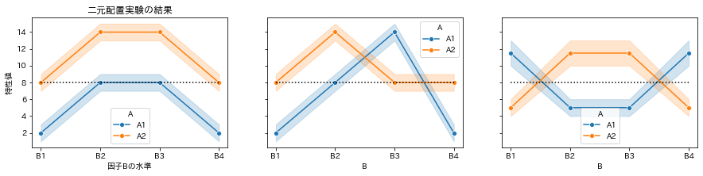

```python
import japanize_matplotlib

# 総平均
total_mean = df['Value'].mean()

# 因子Aと因子Bの水準ごとの平均値を計算
means = df.pivot_table(values='Value', index='A', columns='B', aggfunc="mean")

# 結果を表示
print("\n因子Aと因子Bの水準ごとの平均値:")
print(means)

# グラフ化
fig, ax = plt.subplots(ncols=3, sharex=True, sharey=True,figsize=(15,3))

# 因子Aごとの線グラフ
sns.lineplot(ax = ax[0],data=df, x='B', y='Value',  hue='A', marker='o')
sns.lineplot(ax = ax[1],data=df, x='B', y='Value2', hue='A', marker='o')
sns.lineplot(ax = ax[2],data=df, x='B', y='Value3', hue='A', marker='o')

ax[0].hlines(total_mean,0,3, color='k', linestyles=":")
ax[1].hlines(total_mean,0,3, color='k', linestyles=":")
ax[2].hlines(total_mean,0,3, color='k', linestyles=":")

# グラフのタイトルとラベルを設定
ax[0].set_title('二元配置実験の結果')
ax[0].set_xlabel('因子Bの水準')
ax[0].set_ylabel('特性値')

# グラフを表示
plt.show()
```

## 14.7

因子Aを２水準、因子Bを４水準、繰り返し２回の二元配置実験をランダムな順序で行って、表１４．４の結果を得た。次をもとめよ。

1. 分散分析
2. 母平均が最大となる水準の組み合わせ
3. その場合の母平均の点推定と９５％区間推定

Se llevó a cabo un experimento factorial de dos factores con el factor A en 2 niveles, el factor B en 4 niveles y 2 repeticiones en orden aleatorio, obteniéndose los resultados de la Tabla 14.4. Se pide calcular lo siguiente:

1. Análisis de varianza
2. Combinación de niveles que maximiza la media poblacional
3. Estimación puntual e intervalo de confianza del 95% para la media poblacional en ese caso.

```python
# スプレッドシートを開く（URLまたはスプレッドシートIDを使用）
SPREADSHEET_ID = "1W4H3VxXJwpKGMu0rE9ocz6yA6J0boG9vGzktgsro1es"
sheet = client.open_by_key(SPREADSHEET_ID).worksheet("Sheet14")

# データを取得
list_of_lists = sheet.get_all_records()
df = pd.DataFrame(list_of_lists)

df['r'] = df.groupby(['A','B']).cumcount()+1
df0 = df.copy()

df.pivot_table(index=['r','A'], columns='B', values='Value')

df0
```

|  | A | B | Value | r |
| --- | --- | --- | --- | --- |
| 0 | A1 | B1 | 3 | 1 |
| 1 | A1 | B2 | 8 | 1 |
| 2 | A1 | B3 | 5 | 1 |
| 3 | A1 | B4 | 4 | 1 |
| 4 | A2 | B1 | 7 | 1 |
| 5 | A2 | B2 | 11 | 1 |
| 6 | A2 | B3 | 9 | 1 |
| 7 | A2 | B4 | 6 | 1 |
| 8 | A1 | B1 | 5 | 2 |
| 9 | A1 | B2 | 6 | 2 |
| 10 | A1 | B3 | 6 | 2 |
| 11 | A1 | B4 | 3 | 2 |
| 12 | A2 | B1 | 6 | 2 |
| 13 | A2 | B2 | 10 | 2 |
| 14 | A2 | B3 | 7 | 2 |
| 15 | A2 | B4 | 4 | 2 |

```
ANOVA Table:
           sum_sq   df          F    PR(>F)
C(A)         25.0  1.0  20.000000  0.002077
C(B)         46.0  3.0  12.266667  0.002316
C(A):C(B)     2.0  3.0   0.533333  0.672177
Residual     10.0  8.0        NaN       NaN

Point Estimate of μ22: 10.5

Confidence Interval for μ22: (np.float64(8.963585535143316), np.float64(12.036414464856684))
Effective Replications (Formula de Ina): 3.2
```

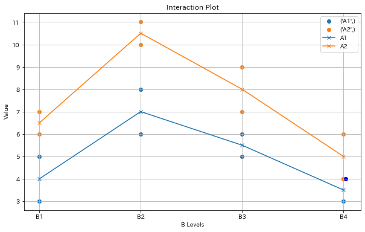

```python
# データの構造式を定義（交互作用項を含む）
model = ols('Value ~ C(A) * C(B)', data=df).fit()
anova_table = sm.stats.anova_lm(model, typ=2)

# ANOVAテーブルの表示
print("ANOVA Table:")
print(anova_table)

df_mean = df.pivot_table(index='A', columns='B', values="Value", aggfunc="mean")

# 因子Aが第2水準、因子Bが第2水準の母平均μ22の点推定値
mu_22 = df[(df['A'] == 'A2') & (df['B'] == 'B2')]['Value'].mean()
print("\nPoint Estimate of μ22:", mu_22)

# 伊奈の式に基づく有効反復数 r_eff の計算
r = 2       # セルA2B2の繰り返し
l = 2
m = 4
inv_r_eff = 1/(m*r) + 1/(l*r) - 1/(l*m*r)
r_eff = 1 / inv_r_eff

# 因子Aが第2水準、因子Bが第2水準の母平均μ22の区間推定
n = len(df[(df['A'] == 'A2') & (df['B'] == 'B2')])  # 有効反復数
sample_mean = mu_22
sample_std = df[(df['A'] == 'A2') & (df['B'] == 'B2')]['Value'].std(ddof=1)
confidence_level = 0.95
alpha = 1 - confidence_level
t_critical = stats.t.ppf(1 - alpha/2, df=r_eff)
margin_of_error = t_critical * (sample_std / np.sqrt(n))

confidence_interval = (sample_mean - margin_of_error, sample_mean + margin_of_error)

print("\nConfidence Interval for μ22:", confidence_interval)
print("Effective Replications (Formula de Ina):", r_eff)

# データの説明のためのグラフを作成
fig, ax = plt.subplots(figsize=(10, 6))
for key, grp in df.groupby(['A']):
    ax.scatter(grp['B'], grp['Value'], marker='o', label=key)
df_mean.T.plot(ax=ax,marker='x')
plt.scatter(3.02,4,color="blue")
ax.legend(loc='best')
plt.xlabel('B Levels')
plt.ylabel('Value')
plt.title('Interaction Plot')
ax.grid(True)
plt.show()
```

```python
import anova # type: ignore
importlib.reload(anova)

from anova import Anova3 # type: ignore

anova = Anova3(df)
anova_table3, message = anova.creacion_Anova3()

print(message)
display(anova_table3)
```

```
l:2 m:4 r:2
SST: 83.00
SSA: 25.00
SSB: 46.00
SSAB: 2.00
SSE: 10.00
DF_A: 1  DF_B: 3  DF_AB: 3  DF_E: 8

【Optimal Condition】
Aの最適条件: A2 Bの最適条件: B2 最大のValue: 10.5
Optimal Mean: 10.50
95% Confidence Interval: [8.676943659746991, 12.323056340253009]
```

|  | sum_sq | df | mean_sq | F | PR(>F) |
| --- | --- | --- | --- | --- | --- |
| A | 25.0 | 1 | 25.000000 | 20.000000 | 0.002077 |
| B | 46.0 | 3 | 15.333333 | 12.266667 | 0.002316 |
| AxB | 2.0 | 3 | 0.666667 | 0.533333 | 0.672177 |
| Residual | 10.0 | 8 | 1.250000 | NaN | NaN |
| Total | 83.0 | 15 | NaN | NaN | NaN |

```python
import anova # type: ignore
importlib.reload(anova)

from anova import Anova5 # type: ignore

anova = Anova5(df)
anova_table3, message = anova.creacion_Anova5()

print(message)
display(anova_table3)
```

```
l:2 m:4 r:2
SST: 83.00
SSA: 25.00
SSB: 46.00
SSAB: 2.00
SSE: 10.00
DF_A: 1  DF_B: 3  DF_AB: 3  DF_E: 8

【Optimal Condition】
Aの最適条件: A2 Bの最適条件: B2 最大のValue: 10.5
Optimal Mean: 10.50
95% Confidence Interval: [8.676943659746991, 12.323056340253009]
```

|  | sum_sq | df | mean_sq | F | PR(>F) |
| --- | --- | --- | --- | --- | --- |
| A | 25.0 | 1 | 25.000000 | 20.000000 | 0.002077 |
| B | 46.0 | 3 | 15.333333 | 12.266667 | 0.002316 |
| AxB | 2.0 | 3 | 0.666667 | 0.533333 | 0.672177 |
| Residual | 10.0 | 8 | 1.250000 | NaN | NaN |
| Total | 83.0 | 15 | NaN | NaN | NaN |

```python
'''
from gspread_dataframe import set_with_dataframe

# スプレッドシートを開く（URLまたはスプレッドシートIDを使用）
SPREADSHEET_ID = "1W4H3VxXJwpKGMu0rE9ocz6yA6J0boG9vGzktgsro1es"
worksheet = client.open_by_key(SPREADSHEET_ID).worksheet("Sheet15")

#set_with_dataframe(worksheet, df)
'''
```

```
'\nfrom gspread_dataframe import set_with_dataframe\n\n# スプレッドシートを開く（URLまたはスプレッドシートIDを使用）\nSPREADSHEET_ID = "1W4H3VxXJwpKGMu0rE9ocz6yA6J0boG9vGzktgsro1es"\nworksheet = client.open_by_key(SPREADSHEET_ID).worksheet("Sheet15")\n\n#set_with_dataframe(worksheet, df)\n'
```

```python
notebook_name = 'QCKentei2-7.ipynb'
notebook_name_html = notebook_name.replace(".ipynb",".html")

!jupyter nbconvert --to html {notebook_name}
```

```
[NbConvertApp] Converting notebook QCKentei2-7.ipynb to html
[NbConvertApp] Writing 1677550 bytes to QCKentei2-7.html
```

```python
from IPython.display import display
from PIL import Image
import gdown
import re

def get_file_id(url,out):
    # 正規表現でファイルIDを抽出
    match = re.search(r'/d/([a-zA-Z0-9_-]+)', url)

    if match:
        file_id = match.group(1)
        print("ファイルID:", file_id)
    else:
        print("ファイルIDが見つかりませんでした。")

    url = f"https://drive.google.com/uc?id={file_id}"

    output = out

    gdown.download(url, output, quiet=False)

    img = Image.open(out)
    display(img)
```

```python
url= 'https://drive.google.com/file/d/1v0wiygaKFLdAOCd16Jq2kT9IERAX2Ueu/view?usp=drive_link'
out = './Data2/7-1.png'
#get_file_id(url,out)
```

```python
url= 'https://drive.google.com/file/d/1W6C-V-_axYIy2xCMaRNAavkcCbjV4vMn/view?usp=drive_link'
out = './Data2/7-13.png'
#get_file_id(url,out)
```

```python
url= 'https://drive.google.com/file/d/1iByEgijHaktfbqsBBQbUbC2LpYNKvfGv/view?usp=drive_link'
out = './Data2/7-12.png'
#get_file_id(url,out)
```

```python
import numpy as np
import pandas as pd

# 因子 A: 2水準, 因子 B: 2水準, 繰り返し: 3回
data = [
    {'A': 'A1', 'B': 'B1', 'Rep': 1, 'Value': 10},
    {'A': 'A1', 'B': 'B1', 'Rep': 2, 'Value': 12},
    {'A': 'A1', 'B': 'B1', 'Rep': 3, 'Value': 11},
    {'A': 'A1', 'B': 'B2', 'Rep': 1, 'Value': 9},
    {'A': 'A1', 'B': 'B2', 'Rep': 2, 'Value': 8},
    {'A': 'A1', 'B': 'B2', 'Rep': 3, 'Value': 10},
    {'A': 'A2', 'B': 'B1', 'Rep': 1, 'Value': 15},
    {'A': 'A2', 'B': 'B1', 'Rep': 2, 'Value': 14},
    {'A': 'A2', 'B': 'B1', 'Rep': 3, 'Value': 13},
    {'A': 'A2', 'B': 'B2', 'Rep': 1, 'Value': 10},
    {'A': 'A2', 'B': 'B2', 'Rep': 2, 'Value': 11},
    {'A': 'A2', 'B': 'B2', 'Rep': 3, 'Value': 9},
]

df = pd.DataFrame(data)

df['Value1'] = np.arange(1,len(df)+1)
df
df
```

|  | A | B | Rep | Value | Value1 |
| --- | --- | --- | --- | --- | --- |
| 0 | A1 | B1 | 1 | 10 | 1 |
| 1 | A1 | B1 | 2 | 12 | 2 |
| 2 | A1 | B1 | 3 | 11 | 3 |
| 3 | A1 | B2 | 1 | 9 | 4 |
| 4 | A1 | B2 | 2 | 8 | 5 |
| 5 | A1 | B2 | 3 | 10 | 6 |
| 6 | A2 | B1 | 1 | 15 | 7 |
| 7 | A2 | B1 | 2 | 14 | 8 |
| 8 | A2 | B1 | 3 | 13 | 9 |
| 9 | A2 | B2 | 1 | 10 | 10 |
| 10 | A2 | B2 | 2 | 11 | 11 |
| 11 | A2 | B2 | 3 | 9 | 12 |

```python
A_levels = sorted(df['A'].unique())  # ['A1', 'A2']
B_levels = sorted(df['B'].unique())  # ['B1', 'B2']
r = df['Rep'].nunique()              # 3

l, m = len(A_levels), len(B_levels)
data_array = np.empty((l, m, r))

for i, a in enumerate(A_levels):
    for j, b in enumerate(B_levels):
        vals = df[(df['A'] == a) & (df['B'] == b)].sort_values('Rep')['Value1'].values
        data_array[i, j, :] = vals
```

```python
data_array
```

```
array([[[ 1.,  2.,  3.],
        [ 4.,  5.,  6.]],

       [[ 7.,  8.,  9.],
        [10., 11., 12.]]])
```

```python
# 総平均
grand_mean = data_array.mean()

# 総平方和（SST）
sst = np.sum((data_array - grand_mean) ** 2)

# 因子Aの平均 → A水準ごとに全体平均
a_means = data_array.mean(axis=(1, 2))  # shape=(2,)
ssa = m * r * np.sum((a_means - grand_mean) ** 2)

# 因子Bの平均
b_means = data_array.mean(axis=(0, 2))  # shape=(2,)
ssb = l * r * np.sum((b_means - grand_mean) ** 2)

# A×Bのセル平均
ab_means = data_array.mean(axis=2)      # shape=(2,2)
ssab = r * np.sum((ab_means - a_means[:, None] - b_means[None, :] + grand_mean) ** 2)

# 誤差平方和（SSE）
sse = sst - ssa - ssb - ssab
```

```python
data_array.mean(axis=2)
```

```
array([[ 2.,  5.],
       [ 8., 11.]])
```

```python
data_array[1,:,:]
```

```
array([[ 7.,  8.,  9.],
       [10., 11., 12.]])
```

```python
a_means[:, None]
```

```
array([[3.5],
       [9.5]])
```

```python
b_means
```

```
array([5., 8.])
```

```python
data_array.sum(axis=2)
```

```
array([[ 6., 15.],
       [24., 33.]])
```

```python
a0 = data_array[0,:,:]
a1 = data_array[1,:,:]
a_means = [a0.mean(), a1.mean()]
a_means
```

```
[np.float64(3.5), np.float64(9.5)]
```

```python
b0 = data_array[:,0,:]
b1 = data_array[:,1,:]
b_means = [b0.mean(), b1.mean()]
b_means
```

```
[np.float64(5.0), np.float64(8.0)]
```

```python
ab_means
```

```
array([[ 2.,  5.],
       [ 8., 11.]])
```

```python
data_array.mean(axis=1)
```

```
array([[ 2.5,  3.5,  4.5],
       [ 8.5,  9.5, 10.5]])
```

```python
arr_zeroed = data_array.copy()
arr_zeroed[:,:,0].sum()
```

```
np.float64(22.0)
```

```python
data_array[0,1,:]
```

```
array([4., 5., 6.])
```

```python
a = list(data_array.shape)
for i in range(l):
        for j in range(m):
            print(i,j,data_array[i,j,:].mean())
```

```
0 0 2.0
0 1 5.0
1 0 8.0
1 1 11.0
```

```python
a[0]
```

```
2
```

```python
l
```

```
2
```